# Building_Energy_Efficiency_part1

## **Multi-Energy Analysis and Forecasting for Building Energy Efficiency: From Data Exploration to Predictive Modeling**

#### A project realised by **Dr. Khalifa Mejbri**, Professor of Engineering, Expert in Data Science and Machine Learning.

## **Introduction**

### **Background and Motivation**

Buildings are responsible for a substantial share of global energy consumption and greenhouse gas emissions. As urbanization accelerates and energy demand increases, improving the energy efficiency of buildings has become a key lever for reducing operational costs and mitigating environmental impact. Energy is consumed through multiple streams—electricity, chilled water, hot water, and steam—each reflecting different systems and end-uses within the built environment. Monitoring, analyzing, and forecasting these consumption patterns is therefore critical for identifying inefficiencies, guiding retrofits, and supporting data-driven decision-making.

### **Project Scope**

This project addresses the challenge of analyzing and predicting building energy efficiency using a large-scale dataset. The work is divided into two complementary parts:

#### **1. Part I – Exploration and Model Development with Labeled Data**

- Conduct **data exploration and descriptive analysis** of historical energy consumption.
- Derive performance indicators such as **Energy Use Intensity (EUI)** to benchmark buildings.
- Train and evaluate predictive models for each energy type (**electricity, chilled water, hot water, steam**).
- Interpret the results to highlight key factors influencing consumption patterns.

#### **2. Part II – Exploitation of Unlabeled Data for Forecasting and Efficiency Insights**

- Apply trained models to unlabeled datasets (future weather, building schedules).
- Perform **forecasting of short-term and long-term loads** to support operational planning.
- Detect anomalies and efficiency deviations to provide actionable insights.
- Explore predictive control strategies for **optimized energy management**.

### **Contribution**

The first part of the project establishes a **baseline understanding** of energy consumption in buildings, both descriptively and predictively. It provides actionable insights into efficiency performance while setting the foundation for the second part, which extends the analysis towards **forecasting, anomaly detection, and predictive optimization**. Taken together, the project aims to bridge **historical energy analysis** with **forward-looking strategies**, ultimately supporting more sustainable and efficient building operations.

# **Part I: Exploration and Model Development with Labeled Data**

```python
# Libraries to help with reading and manipulating data
import pandas as pd
import numpy as np

# Libaries to help with data visualization
import matplotlib.pyplot as plt
import seaborn as sns
sns.set()

# Importing the Machine Learning models we require from Scikit-Learn
from sklearn.linear_model import LogisticRegression
from sklearn.svm import SVC
from sklearn.tree import DecisionTreeClassifier
from sklearn import tree
from sklearn.ensemble import RandomForestClassifier

# Importing the other functions we may require from Scikit-Learn
from sklearn.model_selection import train_test_split, GridSearchCV, cross_val_score
from sklearn.preprocessing import MinMaxScaler, LabelEncoder, OneHotEncoder, StandardScaler
from sklearn.impute import SimpleImputer

# To get diferent metric scores
from sklearn.metrics import accuracy_score,precision_score,recall_score,f1_score,confusion_matrix,roc_auc_score,classification_report,precision_recall_curve,roc_curve,make_scorer

# Code to ignore warnings from function usage
import warnings
warnings.filterwarnings('ignore')
```

```python
# Display all the columns of the dataframe
pd.set_option('display.max_columns', None)
# Display all the rows of the dataframe
pd.set_option('display.max_rows', None)
```

## **Importing the database**

#### **Model Training:**

- Use train.csv + weather_train.csv
- Train model to predict meter_reading from weather and building metadata

#### **Model Prediction**

- Use test.csv + weather_test.csv
- Predict energy usage during test timestamps for each building-meter combo

### **Data description**

#### **1. train.csv**

**Purpose:** Main training dataset containing historical energy usage (meter readings) for various buildings and energy types.

The target variable we are trying to predict is **meter_reading**.

#### **2. test.csv**

**Purpose:** Test dataset for which you are expected to generate predictions.

**Key Columns:**

- **row_id**: Unique identifier for each test row (used for submission)
- **building_id**, **meter**, **timestamp**: Same structure as train.csv, but **without meter_reading**.

#### **3. building_metadata.csv**

**Purpose:** Provides metadata (static features) about each building.

**Key Columns:**

- **site_id**: Location identifier (used to link to weather data)
- **building_id**: Building identifier
- **primary_use**: Type of building usage (e.g., Education, Office)
- **square_feet**: Building size
- **year_built**: Year the building was constructed (many missing)
- **floor_count**: Number of floors (some missing)

Useful for feature engineering (e.g., building age, area normalization)

#### **4. weather_train.csv**

**Purpose:** Weather observations during the training period.

**Key Columns:**

- **site_id**: Links to building site
- **timestamp**: Date and time (hourly)
- **air_temperature**: Degrees Celsius
- **cloud_coverage**: Scale from 0 (clear) to 8 (overcast) or NaN
- **dew_temperature**: Degrees Celsius
- **precip_depth_1_hr**: Precipitation in mm
- **sea_level_pressure**: In millibars (hPa)
- **wind_direction**: Degrees (0–360)
- **wind_speed**: Meters per second

#### **5. weather_test.csv**

**Purpose:** Weather observations during the test period. Same structure and columns as weather_train.csv.

#### **Create dataframe files**

```python
# train dataframe
df_train = pd.read_csv("C:/Disc D/Projects to publish/Projects to do/Energy Efficiency Analytics in Buildings/train.csv")
df_train.shape
```

```
(20216100, 4)
```

```python
df_train.sample(5)
```

|  | building_id | meter | timestamp | meter_reading |
| --- | --- | --- | --- | --- |
| 5491932 | 317 | 0 | 2016-04-13 16:00:00 | 54.090 |
| 7776510 | 799 | 1 | 2016-05-24 07:00:00 | 5035.550 |
| 10050329 | 124 | 0 | 2016-07-03 17:00:00 | 29.600 |
| 20027945 | 653 | 0 | 2016-12-28 16:00:00 | 896.899 |
| 424852 | 1379 | 0 | 2016-01-08 16:00:00 | 114.525 |

```python
# weather_train dataframe
df_weather_train = pd.read_csv("C:/Disc D/Projects to publish/Projects to do/Energy Efficiency Analytics in Buildings/weather_train.csv")
df_weather_train.shape
```

```
(139773, 9)
```

```python
df_weather_train.sample(5)
```

|  | site_id | timestamp | air_temperature | cloud_coverage | dew_temperature | precip_depth_1_hr | sea_level_pressure | wind_direction | wind_speed |
| --- | --- | --- | --- | --- | --- | --- | --- | --- | --- |
| 88622 | 10 | 2016-02-12 07:00:00 | -3.3 | 9.0 | -3.3 | 0.0 | 1033.0 | 330.0 | 1.5 |
| 62247 | 7 | 2016-02-06 22:00:00 | 1.3 | NaN | -3.9 | NaN | 1017.2 | 200.0 | 5.1 |
| 39222 | 4 | 2016-06-20 09:00:00 | 15.0 | 0.0 | 10.6 | 0.0 | 1017.3 | 310.0 | 1.5 |
| 134190 | 15 | 2016-05-05 03:00:00 | 9.4 | NaN | 7.2 | NaN | 1007.3 | 120.0 | 2.1 |
| 9824 | 1 | 2016-02-13 08:00:00 | 3.6 | NaN | 2.4 | NaN | 985.9 | 80.0 | 5.7 |

```python
# building_metadata dataframe
df_building_metadata = pd.read_csv("C:/Disc D/Projects to publish/Projects to do/Energy Efficiency Analytics in Buildings/building_metadata.csv")
df_building_metadata.shape
```

```
(1449, 6)
```

```python
df_building_metadata.sample(5)
```

|  | site_id | building_id | primary_use | square_feet | year_built | floor_count |
| --- | --- | --- | --- | --- | --- | --- |
| 229 | 2 | 229 | Education | 140092 | NaN | NaN |
| 469 | 3 | 469 | Public services | 13044 | 1913.0 | NaN |
| 287 | 2 | 287 | Office | 33713 | 1956.0 | NaN |
| 94 | 0 | 94 | Education | 29469 | 1968.0 | NaN |
| 895 | 9 | 895 | Education | 55087 | NaN | NaN |

## **Preparing the different datasets & converting units**

### **Merging train dataset**

#### **Join train with building_metadata on building_id**

```python
df_train_combined = df_train.merge(df_building_metadata, on="building_id", how="left")
```

```python
df_train_combined.shape
```

```
(20216100, 9)
```

```python
df_train_combined.head()
```

|  | building_id | meter | timestamp | meter_reading | site_id | primary_use | square_feet | year_built | floor_count |
| --- | --- | --- | --- | --- | --- | --- | --- | --- | --- |
| 0 | 0 | 0 | 2016-01-01 00:00:00 | 0.0 | 0 | Education | 7432 | 2008.0 | NaN |
| 1 | 1 | 0 | 2016-01-01 00:00:00 | 0.0 | 0 | Education | 2720 | 2004.0 | NaN |
| 2 | 2 | 0 | 2016-01-01 00:00:00 | 0.0 | 0 | Education | 5376 | 1991.0 | NaN |
| 3 | 3 | 0 | 2016-01-01 00:00:00 | 0.0 | 0 | Education | 23685 | 2002.0 | NaN |
| 4 | 4 | 0 | 2016-01-01 00:00:00 | 0.0 | 0 | Education | 116607 | 1975.0 | NaN |

#### **Join with weather_train on site_id and timestamp**

```python
merged_chunks = []
site_ids = df_train_combined["site_id"].unique()

for site_id in site_ids:
    df_site = df_train_combined[df_train_combined["site_id"] == site_id].copy()
    df_weather_site = df_weather_train[df_weather_train["site_id"] == site_id].copy()

    df_site["timestamp"] = pd.to_datetime(df_site["timestamp"])
    df_weather_site["timestamp"] = pd.to_datetime(df_weather_site["timestamp"])

    df_merged = df_site.merge(df_weather_site, on=["site_id", "timestamp"], how="left")
    merged_chunks.append(df_merged)

# Concatenate all merged chunks
df_train_combined = pd.concat(merged_chunks, ignore_index=True)
```

```python
df_train_combined.shape
```

```
(20216100, 16)
```

```python
df_train_combined.sample(2)
```

|  | building_id | meter | timestamp | meter_reading | site_id | primary_use | square_feet | year_built | floor_count | air_temperature | cloud_coverage | dew_temperature | precip_depth_1_hr | sea_level_pressure | wind_direction | wind_speed |
| --- | --- | --- | --- | --- | --- | --- | --- | --- | --- | --- | --- | --- | --- | --- | --- | --- |
| 19511143 | 1425 | 0 | 2016-08-29 13:00:00 | 188.950 | 15 | Utility | 4071 | 1990.0 | NaN | 20.0 | NaN | 17.8 | NaN | 1023.8 | 330.0 | 3.6 |
| 14965971 | 1126 | 2 | 2016-08-28 01:00:00 | 842.773 | 13 | Education | 72332 | NaN | NaN | 20.6 | NaN | 16.1 | 0.0 | 1016.2 | 0.0 | 0.0 |

### **Convert square_feet to square_meters**

**Conversion factor:** 1 square foot = 0.092903 square meters

```python
df_train_combined["square_meters"] = df_train_combined["square_feet"] * 0.092903
```

### **Convert meter_reading to kWh**

| `meter` | Energy Type | Native Unit | Convert to kWh using |
| --- | --- | --- | --- |
| 0 | Electricity | kWh | Already in kWh |
| 1 | Chilled Water | Ton-hours | `kWh = ton-hour × 3.5168525` |
| 2 | Steam | lb (pounds) | `kWh = lbs × 0.00029307107` |
| 3 | Hot Water | kBtu | `kWh = kBtu × 0.29307107` |

```python
# Rename 'meter' column to 'Energy_type'
df_train_combined.rename(columns={"meter": "Energy_type"}, inplace=True)

# Define conditions for each Energy_type
conditions = [
    df_train_combined["Energy_type"] == 0,
    df_train_combined["Energy_type"] == 1,
    df_train_combined["Energy_type"] == 2,
    df_train_combined["Energy_type"] == 3
]

# Define corresponding multipliers
multipliers = [
    1,                    # Electricity (already in kWh)
    3.5168525,            # Chilled water
    0.00029307107,        # Steam
    0.29307107            # Hot water
]

# Apply the conversion using np.select
df_train_combined["Energy_kWh"] = df_train_combined["meter_reading"] * np.select(conditions, multipliers, default=1)
```

```python
df_train_combined.sample(2)
```

|  | building_id | Energy_type | timestamp | meter_reading | site_id | primary_use | square_feet | year_built | floor_count | air_temperature | cloud_coverage | dew_temperature | precip_depth_1_hr | sea_level_pressure | wind_direction | wind_speed | square_meters | Energy_kWh |
| --- | --- | --- | --- | --- | --- | --- | --- | --- | --- | --- | --- | --- | --- | --- | --- | --- | --- | --- |
| 8686139 | 768 | 0 | 2016-12-10 05:00:00 | 442.217 | 6 | Education | 75929 | NaN | NaN | -2.2 | 0.0 | -10.6 | 0.0 | 1031.7 | 0.0 | 0.0 | 7054.031887 | 442.217 |
| 17064406 | 1259 | 0 | 2016-06-19 21:00:00 | 118.000 | 14 | Education | 71088 | NaN | NaN | 32.2 | NaN | 10.0 | 0.0 | 1022.1 | 0.0 | 0.0 | 6604.288464 | 118.000 |

## **Handling missing values for train dataset**

### **Check percentage of missing values per column**

**This shows what percentage of each column's values are missing — helpful for deciding how to handle them.**

```python
# for train dataset
(df_train_combined.isnull().sum() / len(df_train_combined)) * 100
```

```
building_id            0.000000
Energy_type            0.000000
timestamp              0.000000
meter_reading          0.000000
site_id                0.000000
primary_use            0.000000
square_feet            0.000000
year_built            59.990033
floor_count           82.652772
air_temperature        0.478124
cloud_coverage        43.655131
dew_temperature        0.495348
precip_depth_1_hr     18.544739
sea_level_pressure     6.092515
wind_direction         7.167792
wind_speed             0.710701
square_meters          0.000000
Energy_kWh             0.000000
dtype: float64
```

#### **Missing Data Summary**

| Feature | % Missing | Interpretation & Suggestion |
| --- | --- | --- |
| `year_built` | 60% | High — Impute by `primary_use` or drop |
| `floor_count` | 83% | Very high — likely drop |
| `cloud_coverage` | 44% | Moderate — Impute by `site_id` median |
| `precip_depth_1_hr` | 18.5% | Impute by `site_id` median |
| `sea_level_pressure` | 6% | Impute by `site_id` median |
| `wind_direction` | 7.2% | Impute by `site_id` median |
| `air_temperature` | 0.48% | Forward-fill or median by `site_id` |
| `dew_temperature` | 0.50% | Forward-fill or median by `site_id` |
| `wind_speed` | 0.71% | Forward-fill or median by `site_id` |
| All others | 0% | ✅ Clean and ready |

#### **year_built (≈60% missing)**

**Fill with median per `primary_use`**

```python
# train dataset
df_train_combined["year_built"] = df_train_combined.groupby("primary_use")["year_built"].transform(
    lambda x: x.fillna(x.median())
)
```

#### **floor_count (≈83% missing)**

**Too sparse for reliable imputation. We recommand dropping this column.**

```python
df_train_combined.drop(columns=["floor_count"], inplace=True)
```

```python
df_train_combined.columns
```

```
Index(['building_id', 'Energy_type', 'timestamp', 'meter_reading', 'site_id',
       'primary_use', 'square_feet', 'year_built', 'air_temperature',
       'cloud_coverage', 'dew_temperature', 'precip_depth_1_hr',
       'sea_level_pressure', 'wind_direction', 'wind_speed', 'square_meters',
       'Energy_kWh'],
      dtype='object')
```

**The column `floor_count` is dropped.**

### **Weather Data:**

**These are important for energy forecasting, so imputing is better than dropping.**

- **`air_temperature`**, **`dew_temperature`**, **`wind_speed`**: Very low missing % → simple forward fill per **`site_id`** is safe.

```python
# Sort the df_train_combined dataframe per "site_id", "timestamp"
df_train_combined.sort_values(["site_id", "timestamp"], inplace=True)

# filling the missing values
for col in ["air_temperature", "dew_temperature", "wind_speed"]:
    df_train_combined[col] = df_train_combined.groupby("site_id")[col].transform(lambda x: x.ffill().bfill())
```

- **`cloud_coverage`** (≈44%), **`precip_depth_1_hr`** (≈18.5%), **`sea_level_pressure`** (≈6%), **`wind_direction`** (≈7%)

**These vary more and are still useful. Fill using site-level median.**

```python
# filling the missing values
for col in ["cloud_coverage", "sea_level_pressure", "wind_direction"]:
    df_train_combined[col] = df_train_combined.groupby("site_id")[col].transform(
        lambda x: x.fillna(x.median())
    )
```

```python
df_train_combined['precip_depth_1_hr'].value_counts()
```

```
precip_depth_1_hr
 0.0      14517573
-1.0       1093352
 3.0        255539
 5.0        119239
 8.0         72511
 10.0        60741
 13.0        43236
 15.0        34040
 2.0         33970
 18.0        29124
 20.0        22384
 23.0        14715
 25.0        12936
 30.0        12229
 33.0        11955
 28.0         9780
 38.0         8209
 41.0         7807
 36.0         7215
 7.0          6657
 43.0         6399
 53.0         4708
 46.0         4574
 48.0         4021
 66.0         3849
 17.0         3408
 61.0         3202
 56.0         3120
 51.0         3049
 71.0         2734
 64.0         2537
 6.0          2506
 12.0         2247
 91.0         2146
 58.0         2075
 4.0          1895
 79.0         1644
 81.0         1451
 69.0         1389
```

[output cut: 75 more lines]

```
 109.0          77
 103.0          56
 105.0          56
 32.0           56
 217.0          55
 113.0          55
 42.0           55
 47.0           54
 98.0           54
 164.0          54
 162.0          54
 83.0           54
 201.0          54
 73.0           46
Name: count, dtype: int64
```

#### **Treating the 'precip_depth_1_hr' feature**

```python
# Ensure the column is numeric (useful if it contains non-numeric types or is object dtype)
df_train_combined['precip_depth_1_hr'] = pd.to_numeric(df_train_combined['precip_depth_1_hr'], errors='coerce')

# Replace -1 (which likely represents missing values) with NaN
df_train_combined['precip_depth_1_hr'].replace(-1, np.nan, inplace=True)

# Fill missing values based on site_id group median
df_train_combined['precip_depth_1_hr'] = df_train_combined.groupby("site_id")['precip_depth_1_hr'].transform(
    lambda x: x.fillna(x.median())
)
```

```python
# check if there are remaining nan values
df_train_combined['precip_depth_1_hr'].isna().sum()
```

```
1651042
```

**Check 1: Are all site_id groups fully missing?**

```python
# Count missing values per site_id group
missing_per_site = df_train_combined.groupby("site_id")["precip_depth_1_hr"].apply(lambda x: x.isna().sum())
total_per_site = df_train_combined.groupby("site_id")["precip_depth_1_hr"].size()

# Print groups where all values are missing
print(missing_per_site[missing_per_site == total_per_site])
```

```
site_id
1     553357
5     781776
12    315909
Name: precip_depth_1_hr, dtype: int64
```

**For the following site_id groups:**

- site_id = 1 → 553,357 rows
- site_id = 5 → 781,776 rows
- site_id = 12 → 315,909 rows

**All rows are missing (NaN) for 'precip_depth_1_hr', meaning:**

- .median() is NaN for these groups,
- So the group-wise imputation didn’t fill anything for them,
- That’s why 1,651,042 NaNs remain — it’s exactly the sum of those three groups.

```python
# Check for incorrect dtypes
df_train_combined['precip_depth_1_hr'].dtype
```

```
dtype('float64')
```

**The data type of 'precip_depth_1_hr' is numeric.**

**Check 2: Apply fallback imputation for rows still missing**

```python
# Step 1: Group-wise median fill
df_train_combined['precip_depth_1_hr'] = df_train_combined.groupby("site_id")['precip_depth_1_hr'].transform(
    lambda x: x.fillna(x.median())
)

# Step 2: Fallback fill with global median
df_train_combined['precip_depth_1_hr'].fillna(df_train_combined['precip_depth_1_hr'].median(), inplace=True)
```

```python
# check if there are remaining nan values
df_train_combined['precip_depth_1_hr'].isna().sum()
```

```
0
```

**Now there are no missing value for 'precip_depth_1_hr' feature.**

```python
# Checking missing values for train dataset
(df_train_combined.isnull().sum() / len(df_train_combined)) * 100
```

```
building_id           0.000000
Energy_type           0.000000
timestamp             0.000000
meter_reading         0.000000
site_id               0.000000
primary_use           0.000000
square_feet           0.000000
year_built            0.477436
air_temperature       0.000000
cloud_coverage        2.404717
dew_temperature       0.000000
precip_depth_1_hr     0.000000
sea_level_pressure    3.867096
wind_direction        0.000000
wind_speed            0.000000
square_meters         0.000000
Energy_kWh            0.000000
dtype: float64
```

#### **Interpretations**

- **Clean Features (0% missing now):** `air_temperature`, `dew_temperature`, `wind_speed`, `wind_direction`, `meter_reading`, `Energy_kWh`, `timestamp`, etc.
  - These features are fully imputed or clean — ready for modeling.
  - Implication: We can safely use them in training our model without further preprocessing.
- **Still Partially Missing**

| Feature | % Missing | Interpretation & Recommendation |
| --- | --- | --- |
| `year_built` | 0.48% | Significant improvement from 60%. Only a tiny fraction left — fill with median if needed. |
| `cloud_coverage` | 2.4% | Was 44%, now much better — just top up using median by site or global median. |
| `sea_level_pressure` | 3.87% | Low enough to use median by `site_id`. Could indicate faulty sensors at certain times. |

- **Why Are Some Still Missing?**

Even after forward and backward filling, missing values may persist if:

- They appear at the very beginning or end of the dataset (no value to fill from).
- The imputation was only partial due to missing group context (`site_id`, `timestamp`).
- Some methods (like median()) only apply to numeric values, so object types or NaNs tied to specific combinations may remain.

```python
# Final fill step using global median for numeric columns
for col in df_train_combined.select_dtypes(include='number'):
    median_val = df_train_combined[col].median()
    df_train_combined[col].fillna(median_val, inplace=True)
```

```python
# checking missing values for train dataset
(df_train_combined.isnull().sum() / len(df_train_combined)) * 100
```

```
building_id           0.0
Energy_type           0.0
timestamp             0.0
meter_reading         0.0
site_id               0.0
primary_use           0.0
square_feet           0.0
year_built            0.0
air_temperature       0.0
cloud_coverage        0.0
dew_temperature       0.0
precip_depth_1_hr     0.0
sea_level_pressure    0.0
wind_direction        0.0
wind_speed            0.0
square_meters         0.0
Energy_kWh            0.0
dtype: float64
```

**Now there are no missing values in the train dataset.**

```python
# Check the shape of "df_train_combined" dataframe
df_train_combined.shape
```

```
(20216100, 17)
```

**The train dataset is composed of 20216100 rows and 17 features**

## **Feature Engineering**

#### **Enhance the dataset by adding useful time-based and interaction features**

### **Time-based Features**

Energy usage in buildings often follows clear temporal patterns driven by human activity, weather, and operational schedules. To help our model capture these dynamics, we extract and engineer several time-related features from the **timestamp** column:

- **hour**: Represents the hour of the day (0–23), useful for capturing daily usage cycles such as peak working hours.
- **dayofweek**: Represents the day of the week (0 = Monday, 6 = Sunday), which helps model weekday vs weekend behavior.
- **month**: Represents the month of the year (1–12), capturing seasonal variations in energy consumption.
- **is_weekend**: A binary feature that flags whether the timestamp falls on a weekend (Saturday or Sunday), often associated with lower energy demand in commercial or educational buildings.

```python
# train dataset
df_train_combined["hour"] = pd.to_datetime(df_train_combined["timestamp"]).dt.hour
df_train_combined["dayofweek"] = pd.to_datetime(df_train_combined["timestamp"]).dt.dayofweek
df_train_combined["month"] = pd.to_datetime(df_train_combined["timestamp"]).dt.month
df_train_combined["is_weekend"] = df_train_combined["dayofweek"] >= 5
```

- **is_work_hour** — 1 during business hours on weekdays, else 0
- **season** — Categorical feature: "Winter", "Spring", "Summer", or "Autumn"

```python
# Work hours: 8 AM to 6 PM (exclusive), and not on weekends
df_train_combined["is_work_hour"] = (
    (df_train_combined["hour"].between(8, 17)) & (~df_train_combined["is_weekend"])
).astype(int)

# Assign season based on month
conditions = [
    df_train_combined["month"].isin([12, 1, 2]),
    df_train_combined["month"].isin([3, 4, 5]),
    df_train_combined["month"].isin([6, 7, 8])
]
choices = ["Winter", "Spring", "Summer"]

df_train_combined["season"] = np.select(conditions, choices, default="Autumn")
```

#### **Cyclical encodings (sin/cos)**

These features (`hour`, `dayofweek` and `month`) will also be transformed using **cyclical encodings (sin/cos)** to preserve their periodic nature, which is especially helpful for machine learning models that do not inherently understand such cycles.

```python
# Cyclical encoding for 'hour' (24-hour cycle)
df_train_combined['hour_sin'] = np.sin(2 * np.pi * df_train_combined['hour'] / 24)
df_train_combined['hour_cos'] = np.cos(2 * np.pi * df_train_combined['hour'] / 24)

# Cyclical encoding for 'dayofweek' (7-day cycle)
df_train_combined['dayofweek_sin'] = np.sin(2 * np.pi * df_train_combined['dayofweek'] / 7)
df_train_combined['dayofweek_cos'] = np.cos(2 * np.pi * df_train_combined['dayofweek'] / 7)

# Cyclical encoding for 'month' (12-month cycle)
df_train_combined['month_sin'] = np.sin(2 * np.pi * df_train_combined['month'] / 12)
df_train_combined['month_cos'] = np.cos(2 * np.pi * df_train_combined['month'] / 12)

# One-hot encode 'is_weekend'
df_train_combined['is_weekend'] = df_train_combined['is_weekend'].astype(int)  # Already binary, no change needed
```

### **Feature Engineering of `year_built`**

- **Building Age (`building_age`)**: Convert year to building age (e.g., 2025 - year_built). Older buildings may have poorer insulation or outdated systems.
- **Decade or Era (`era_bin`)**: Group years into bins (e.g., before 1960, 1960s–1980s, post-2000). Useful for capturing regulatory/code changes.
- **Renovation Proxy (`is_modern_building`)**: If data on renovations isn't available, create a flag for "modern building" (e.g., built after 2010).

```python
current_year = 2025

# Age of building
df_train_combined['building_age'] = current_year - df_train_combined['year_built']

# Era binning
df_train_combined['era_bin'] = pd.cut(df_train_combined['year_built'],
                       bins=[0, 1960, 1980, 2000, 2010, 2025],
                       labels=['Pre-1960', '60–80', '80–2000', '2000–2010', 'Post-2010'])

# Modern building flag
df_train_combined['is_modern_building'] = (df_train_combined['year_built'] >= 2010).astype(int)
```

### **Create the `energy_density_kwh_m2` feature**

```python
df_train_combined['energy_density_kwh_m2'] = df_train_combined['Energy_kWh'] / df_train_combined['square_meters']
```

```python
df_train_combined.shape
```

```
(20216100, 33)
```

**After feature engineering, the train dataset is composed 33 columns.**

## **Exploratory Data Analysis (EDA)**

### **1. Target Variable Exploration**

**Goal**: Understand the distribution of Energy_kWh

**Add a Readable Label Column**

```python
energy_type_map = {
    0: "Electricity",
    1: "Chilled Water",
    2: "Steam",
    3: "Hot Water"
}

df_train_combined['Energy_type_label'] = df_train_combined['Energy_type'].map(energy_type_map)
```

### **Energy type count distribution**

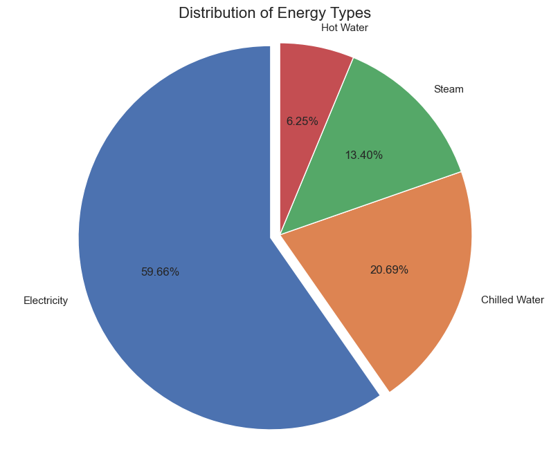

```python
# Count of each energy type
energy_counts = df_train_combined['Energy_type_label'].value_counts()
labels = energy_counts.index
sizes = energy_counts.values

# Optional: explode the largest slice to emphasize it
explode = [0.05 if i == max(sizes) else 0 for i in sizes]

# Create pie chart
fig1, ax1 = plt.subplots(figsize=(10, 8))
ax1.pie(sizes, explode=explode, labels=labels, autopct='%1.2f%%',
        shadow=False, startangle=90)
ax1.axis('equal')  # Equal aspect ratio ensures pie is drawn as a circle
plt.title("Distribution of Energy Types", fontsize=16)
plt.show()
```

#### **Interpretations**

The dataset is heavily dominated by **electricity**, which accounts for **59.7%** of the records. This suggests that electricity is the most widely used or most frequently measured energy source across the buildings in the dataset.

**In contrast:**

- **Chilled water** represents **20.7%**, indicating a significant but more specialized usage—typically linked to cooling systems in larger commercial or institutional buildings.
- **Steam** makes up **13.4%**, often used in heating or industrial applications.
- **Hot water** is the least common, at **6.2%**, potentially reflecting its limited use in specific heating contexts.

This imbalance in distribution means that any model or analysis may **need to account for the dominance of electricity**, possibly through balancing techniques or stratified evaluation. It also highlights **electricity as a key area for energy efficiency optimization due to its prevalence**.

### **Distribution of energy consumption for each energy type**

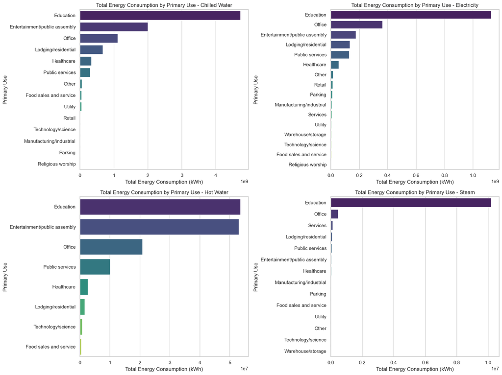

```python
# Optional: set a style
sns.set(style="whitegrid")

# Grouping: mean energy consumption by Energy_type and primary_use
energy_usage = df_train_combined.groupby(['Energy_type_label', 'primary_use'])['Energy_kWh'].sum().reset_index()

# Unique energy types
energy_types = energy_usage['Energy_type_label'].unique()

# Create 2x2 subplots
fig, axes = plt.subplots(2, 2, figsize=(16, 12))
axes = axes.flatten()

# Plotting each energy type
for i, energy_type in enumerate(energy_types):
    ax = axes[i]
    subset = energy_usage[energy_usage['Energy_type_label'] == energy_type]

    # Sort for better visuals (optional)
    subset = subset.sort_values(by='Energy_kWh', ascending=False)

    sns.barplot(x='Energy_kWh', y='primary_use', data=subset, ax=ax, palette='viridis')
    ax.set_title(f'Total Energy Consumption by Primary Use - {energy_type}')
    ax.set_xlabel('Total Energy Consumption (kWh)')
    ax.set_ylabel('Primary Use')

# Hide any unused subplot
if len(energy_types) < 4:
    for j in range(len(energy_types), 4):
        fig.delaxes(axes[j])

plt.tight_layout()
plt.show()
```

#### **Interpretations:**

**1. Chilled Water**

**Chilled water** shows very high total energy consumption, especially in:

- **Education (4.72B kWh)** – the top consumer among all.
- **Entertainment/Public Assembly (2.00B kWh)** and **Office buildings (1.11B kWh)** – strong contributors.

These are typically large facilities with HVAC needs, explaining their high chilled water usage for cooling.

**2. Electricity**

**Electricity** is broadly used across all sectors, with top total consumers being:

- **Office buildings (364M kWh)**
- **Education (1.13B kWh)**
- **Public Services (130M kWh)**
- **Lodging/Residential (133M kWh)**

**Electricity** powers lighting, computers, HVAC, etc., making it essential across all building types. Education again leads, indicating energy-intensive campuses.

**3. Hot Water**

Less prevalent but still significant in:

- **Office buildings (20.8M kWh)**
- **Education (53.5M kWh)**
- **Entertainment/Public Assembly (53M kWh)**

**Hot water** may be used in heating systems or restrooms, primarily in institutions and public spaces with high occupancy.

**4. Steam**

Steam has the lowest overall usage, and is concentrated in:

- **Education (10.2M kWh)**
- **Office (457k kWh)**
- **Public Services (67k kWh)**

**Steam** is specialized and possibly used in district heating or older infrastructure systems—mostly in older institutional buildings.

**Overall Insights**

- **Education buildings** dominate energy consumption across almost all energy types. They are large, multi-purpose, and likely operate extended hours.
- **Offices** are consistent consumers of all energy types, reflecting their central role in the building stock.
- **Chilled water** is the most concentrated energy type, with massive consumption by a few building categories.
- **Steam** is rare and minimal, possibly due to modernization or being phased out.

### **Distribution of energy density for each energy type**

```python
# Group by energy type and primary use using energy density
energy_density_usage = df_train_combined.groupby(['Energy_type_label', 'primary_use'])['energy_density_kwh_m2'].mean().reset_index()
```

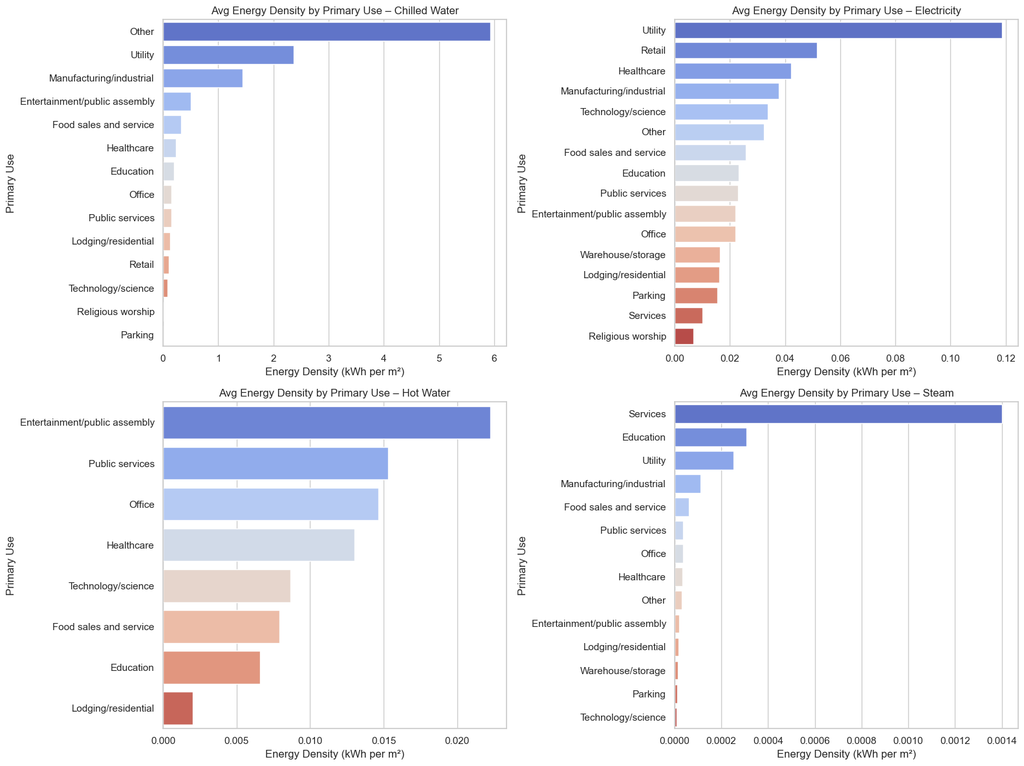

```python
# Style
sns.set(style="whitegrid")

# Unique energy types
energy_types = energy_density_usage['Energy_type_label'].unique()

# Create 2x2 subplots
fig, axes = plt.subplots(2, 2, figsize=(16, 12))
axes = axes.flatten()

# Plotting
for i, energy_type in enumerate(energy_types):
    ax = axes[i]
    subset = energy_density_usage[energy_density_usage['Energy_type_label'] == energy_type]

    # Sort by density for clarity
    subset = subset.sort_values(by='energy_density_kwh_m2', ascending=False)

    sns.barplot(
        x='energy_density_kwh_m2',
        y='primary_use',
        data=subset,
        ax=ax,
        palette='coolwarm'
    )
    ax.set_title(f'Avg Energy Density by Primary Use – {energy_type}')
    ax.set_xlabel('Energy Density (kWh per m²)')
    ax.set_ylabel('Primary Use')

# Remove unused subplots if fewer than 4 types
if len(energy_types) < 4:
    for j in range(len(energy_types), 4):
        fig.delaxes(axes[j])

plt.tight_layout()
plt.show()
```

#### **Interpretations:**

**1. Chilled Water – Highest Energy Density Overall**

- **“Other” (5.93 kWh/m²)** and **Utility (2.37 kWh/m²)** show very high energy densities – likely small in floor area but intensive in cooling needs (e.g., data centers, mechanical rooms).
- **Manufacturing/Industrial (1.44)** and **Entertainment/Public Assembly (0.50)** are also high.
- Common uses like **Office (0.15)** and **Education (0.20)** have moderate density, which reflects steady cooling use over larger areas.

**Chilled water** is used most intensively in spaces requiring heavy cooling (e.g., industrial processes, specialized equipment, or large occupant loads). Lower values in Retail, Religious Worship, and Parking suggest limited need for chilled water.

**2. Electricity – Moderate, Widely Distributed Energy Density**

- **Utility (0.12)** and **Retail (0.05)** have the highest densities.
- Most categories fall **between 0.02–0.04 kWh/m²**, such as **Education (0.023)**, **Office (0.022)**, **Healthcare (0.042)**.
- **Religious Worship (0.0067)** and **Services (0.0099)** show minimal consumption.

**Electricity** consumption per m² is relatively stable across sectors. The slightly higher intensity in Healthcare and Retail reflects lighting, equipment, and HVAC demands.

**3. Hot Water – Low but Targeted Energy Density**

**Hot water** usage is modest and more common in high-occupancy buildings (e.g., offices, entertainment venues), likely used in bathrooms or kitchens.

**4. Steam – Negligible Energy Density**

- All values are extremely low (mostly **less than 0.001 kWh/m²**).
- Slightly higher in **Services (0.0014)** and **Utility (0.00025)**, but still minimal.

**Steam** appears nearly phased out or used in extremely limited cases. Low density suggests very low reliance across modern buildings.

**Overall Insights**

- **Chilled Water** dominates in energy density, especially in niche or specialized buildings (e.g., "Other", Utilities).
- **Electricity** is the most balanced and widespread in terms of energy density, essential for all operations.
- **Hot Water** is used sparingly, with targeted presence.
- **Steam** is nearly obsolete, based on density.

### **2. Temporal Patterns**

**Goal:** Identify hourly, weekly, and seasonal trends in energy consumption (Energy_kWh).

This can help reveal **load patterns**, **peak usage periods**, and **potential anomalies** for energy management.

#### **A. Hourly Patterns**

Visualize how energy consumption varies throughout the day.

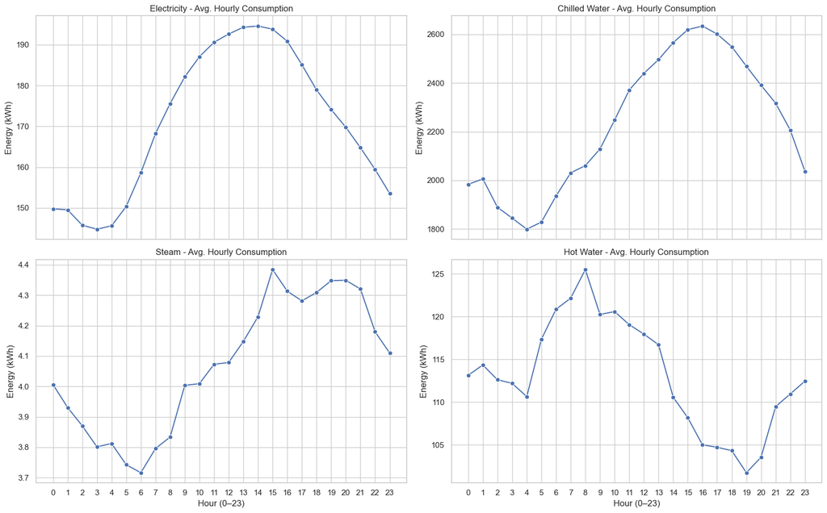

```python
# Group by hour and energy type
hourly_energy = df_train_combined.groupby(["hour", "Energy_type_label"])["Energy_kWh"].mean().reset_index()

# Define energy types
energy_types = ["Electricity", "Chilled Water", "Steam", "Hot Water"]

# Set up 2x2 subplot (no shared y-axis)
fig, axes = plt.subplots(2, 2, figsize=(16, 10), sharex=True)
axes = axes.flatten()

for i, energy in enumerate(energy_types):
    subset = hourly_energy[hourly_energy["Energy_type_label"] == energy]
    sns.lineplot(data=subset, x="hour", y="Energy_kWh", marker="o", ax=axes[i])
    axes[i].set_title(f"{energy} - Avg. Hourly Consumption")
    axes[i].set_xlabel("Hour (0–23)")
    axes[i].set_ylabel("Energy (kWh)")
    axes[i].grid(True)
    axes[i].set_xticks(range(0, 24))

plt.tight_layout()
plt.show()
```

#### **Interpretations:**

**1. Electricity**

- **Peak usage:** Between 10 AM and 5 PM, with a maximum average around 194 kWh at 1–3 PM.
- **Lowest usage:** Between 2 AM and 4 AM (~145 kWh).
- **Pattern:** A classic daily curve with a gradual rise in the morning, peak during business hours, and a decline in the evening.

This reflects normal building occupancy and activity patterns — likely driven by lighting, HVAC, and equipment in commercial/office spaces.

**2. Chilled Water**

- **Peak usage:** Around 4 PM (~2634 kWh).
- **Lowest usage:** Around 3–5 AM (~1800 kWh).
- **Pattern:** Very pronounced daytime peak, sharp increase starting around 6 AM, peaking mid-afternoon, then gradually declining.

Strongly correlated with cooling demands during the daytime. Reflects HVAC operation aligned with outside temperature and building occupancy.

**3. Hot Water**

Tied to domestic or lodging use (e.g., showers, kitchens), possibly educational or healthcare facilities as well.

Used for heating or industrial processes, but overall demand is minimal compared to other energy types. Small variations might reflect basic load or background services.

**Overall Insights**

- **Chilled Water dominates** energy usage in terms of scale, particularly during hot hours (midday–afternoon).
- **Electricity** is steady and significant, peaking during business hours.
- **Hot Water** and **Steam** have **lower magnitudes** and reflect more specialized or background functions.
- Patterns align with **human activity cycles** and **HVAC operation schedules**, which is useful for **load forecasting**, **efficiency planning**, and **demand response** strategies.

#### **B. Weekly Trends – Day of Week by primary use**

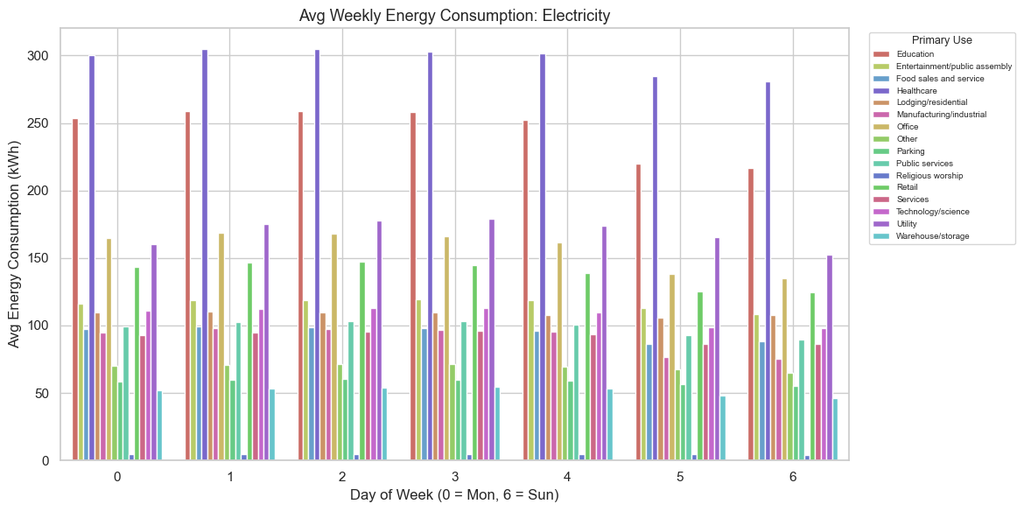

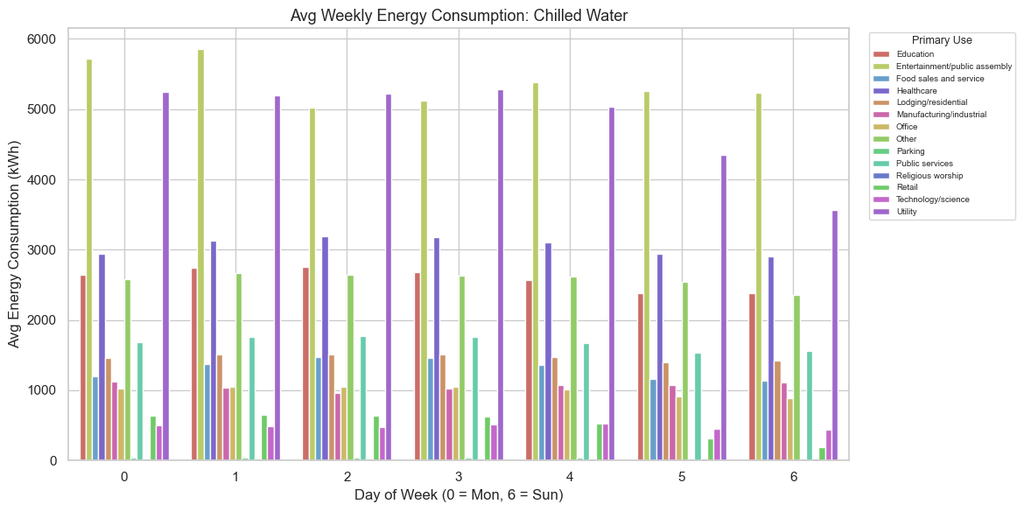

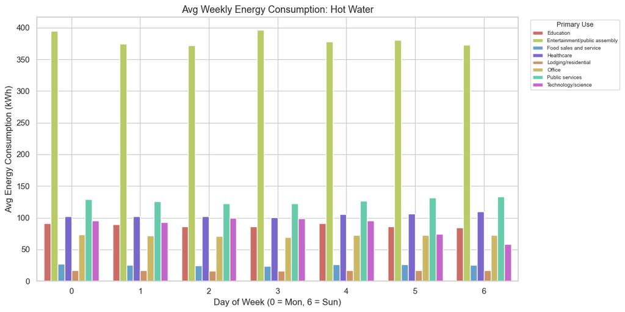

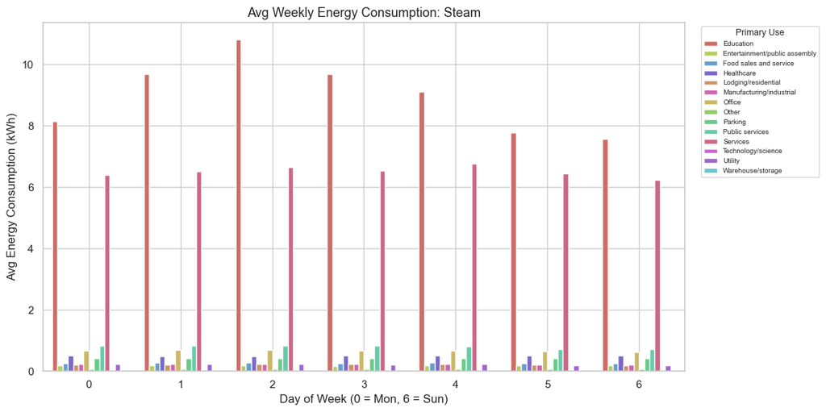

```python
# Compute average energy consumption per day, per energy type, and per primary use
avg_energy_weekday = (
    df_train_combined
    .groupby(['dayofweek', 'Energy_type_label', 'primary_use'])['Energy_kWh']
    .mean()
    .reset_index()
)

# List of energy types
energy_types = ['Electricity', 'Chilled Water', 'Hot Water', 'Steam']

# Unique primary uses and distinct color assignment
primary_uses = df_train_combined["primary_use"].unique()
color_palette = sns.color_palette("hls", n_colors=len(primary_uses))
color_dict = dict(zip(primary_uses, color_palette))

for energy in energy_types:
    subset = avg_energy_weekday[avg_energy_weekday["Energy_type_label"] == energy]

    plt.figure(figsize=(14, 6))
    sns.barplot(
        x="dayofweek",
        y="Energy_kWh",
        hue="primary_use",
        data=subset,
        palette=color_dict
    )
    plt.title(f"Avg Weekly Energy Consumption: {energy}", fontsize=13)
    plt.xlabel("Day of Week (0 = Mon, 6 = Sun)")
    plt.ylabel("Avg Energy Consumption (kWh)")
    plt.grid(True)

    plt.legend(
        title="Primary Use",
        fontsize=7,
        title_fontsize=9,
        bbox_to_anchor=(1.02, 1),
        loc='upper left'
    )

    plt.tight_layout(rect=[0, 0, 0.85, 1])
    plt.show()
```

#### **Interpretations**

**1. Electricity Consumption**

**2. Chilled Water Consumption**

**Key Insights:**

- **Chilled water** is driven by indoor climate control, peaking when occupancy and equipment use is highest.
- **Hospitals** and **Labs** show flat consumption → indicating non-stop climate control requirements.

**3. Hot Water Consumption**

**Key Insights:**

- Hot water demand reflects **domestic-like needs** (e.g., kitchens, showers), more constant in **residential** or **hospitality**-like settings.
- Slight dips in **weekday-only** buildings reinforce use for **cleaning or catering** in working hours.

**4. Steam Consumption**

**Patterns Observed:**

- Generally **low across all buildings**.
- **Hospitals** and **Labs** show consistent use throughout the week.
- **Education** and **Office** buildings have small dips on weekends.

**Key Insights:**

- Steam is likely used for **heating, sterilization**, or **humidification**.
- Stable demand in **Healthcare** points to critical processes (e.g., sterilizing equipment, heating systems).

**5. Cross-Energy Insights**

| **Energy Type** | **Consistent Use (24/7)** | **Weekday-Only Use** |
| --- | --- | --- |
| Electricity | Hospitals, Lodging | Education, Office, Government |
| Chilled Water | Healthcare, Labs | Education, Office |
| Hot Water | Lodging, Healthcare | Education (reduced on weekends) |
| Steam | Labs, Hospitals | Most others (minimal usage) |

**6. Recommendations:**

#### **C. Monthly & Seasonal Trends**

Understanding how energy consumption changes over time is crucial for **forecasting, capacity planning, and identifying climate-sensitive loads**. We explore two time aggregations:

- **Monthly Trends** Captures gradual patterns, such as cooling demand in summer.
- **Seasonal Trends:** Easier for stakeholders to interpret and analyze cyclical energy behavior.

**1. Average Monthly Energy Consumption**

Plotting the mean energy consumption for each month

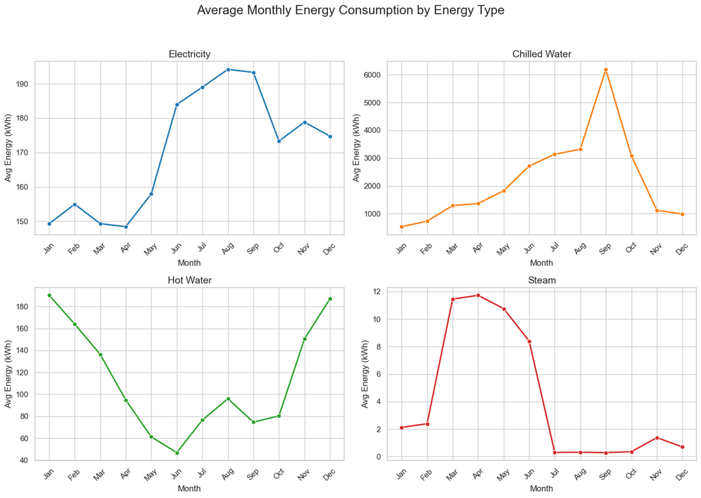

```python
# Group by month and energy type, then compute average energy consumption
df_monthly_energy_type = (df_train_combined.groupby(["month", "Energy_type_label"])["Energy_kWh"].mean().reset_index())

energy_types = ['Electricity', 'Chilled Water', 'Hot Water', 'Steam']

fig, axes = plt.subplots(2, 2, figsize=(14, 10))
fig.suptitle("Average Monthly Energy Consumption by Energy Type", fontsize=18)

for ax, energy in zip(axes.flatten(), energy_types):
    subset = df_monthly_energy_type[df_monthly_energy_type["Energy_type_label"] == energy]
    sns.lineplot(
        data=subset,
        x="month",
        y="Energy_kWh",
        marker="o",
        linewidth=2,
        ax=ax,
        color=sns.color_palette("tab10")[energy_types.index(energy)]
    )
    ax.set_title(energy, fontsize=14)
    ax.set_xlabel("Month")
    ax.set_ylabel("Avg Energy (kWh)")
    ax.set_xticks(range(1, 13))
    ax.set_xticklabels(["Jan", "Feb", "Mar", "Apr", "May", "Jun",
                        "Jul", "Aug", "Sep", "Oct", "Nov", "Dec"], rotation=45)
    ax.grid(True)

plt.tight_layout(rect=[0, 0, 1, 0.95])
plt.show()
```

#### **Interpretations:**

The following analysis breaks down the average monthly energy consumption for each energy type.

**1. Electricity**

The monthly **electricity distribution**:

- Shows a gradual increase **from winter to summer**.
- Peaks in **August–September**, likely due to higher cooling loads and extended occupancy.
- Consistent year-round usage, indicating baseline power needs in most facilities.
- Commonly consumed by hospitals, residential buildings, and offices operating 24/7.

**2. Chilled Water**

- **Month Range:** Min (Jan) ~531.7 kWh, and Max (Sep) ~6192.6 kWh.

The monthly **chilled water distribution**:

- Displays a steep rise from **March through September**.
- Peak consumption in **September**, signaling intense HVAC usage.
- Usage plummets during **winter months**.
- Mainly driven by cooling demands in healthcare, laboratories, and commercial buildings.

**3. Hot Water**

- **Month Range:** Max (Jan) ~190.2 kWh, and Min (Jun) ~46.8 kWh.

The monthly **hot water distribution**:

- Strong **winter seasonality**, with the highest demand in **January**.
- Usage drops sharply during **summer**, particularly in **June–July**.
- Indicates heating needs in colder months for lodging, healthcare, and partially for education.
- Moderate usage year-round, but clearly influenced by outdoor temperatures.

**4. Steam**

- **Month Range:** Max (Apr) ~11.7 kWh, and Min (Jul–Sep) ~0.3 kWh.

The monthly **steam distribution**:

- Lowest consumption across all types, with a non-linear pattern.
- Peaks in **spring** (especially **April**), possibly due to sterilization or industrial processes.
- Very low to no usage in **summer**, highlighting specialized, non-continuous application.
- Likely limited to labs, hospitals, and some older heating systems.

**5. Summary Table**

| Energy Type | Seasonal Pattern | Peak Months | Usage Consistency |
| --- | --- | --- | --- |
| Electricity | Moderate summer increase | Jul–Sep | High |
| Chilled Water | Strong summer peak | Aug–Sep | Low in winter |
| Hot Water | Strong winter use | Jan | Medium |
| Steam | Spring-biased, irregular | Apr | Low |

**2. Seasonal Patterns for Each Energy Type**

```python
# Add Season Column
def assign_season(month):
    if month in [12, 1, 2]:
        return "Winter"
    elif month in [3, 4, 5]:
        return "Spring"
    elif month in [6, 7, 8]:
        return "Summer"
    else:
        return "Autumn"

df_train_combined["season"] = df_train_combined["month"].apply(assign_season)
```

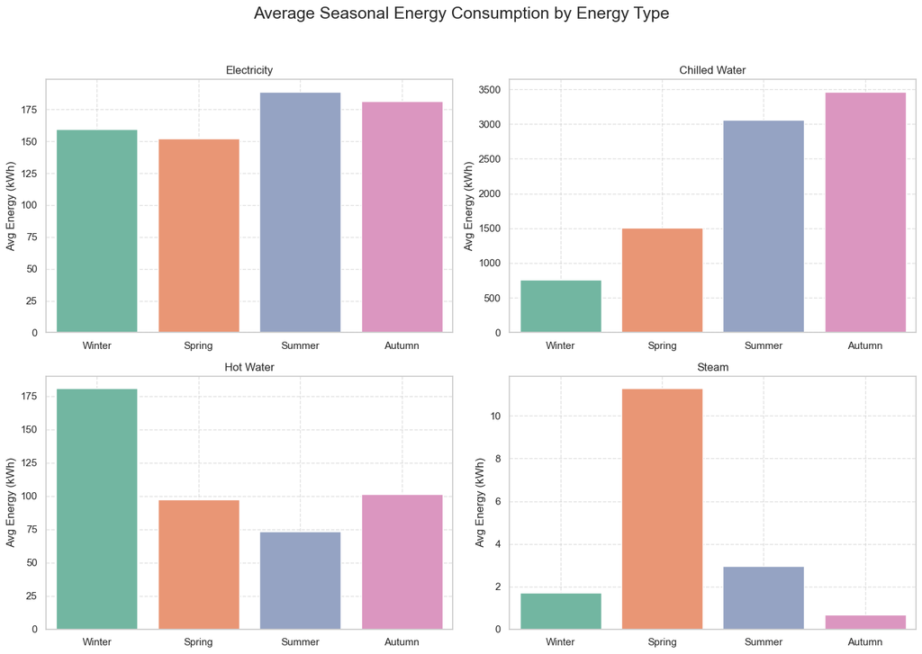

```python
# Group by season and energy type, then compute the mean
seasonal_means = (df_train_combined.groupby(["season", "Energy_type_label"])["Energy_kWh"].mean().reset_index())

# Set the plotting order of seasons
season_order = ["Winter", "Spring", "Summer", "Autumn"]
energy_types = ['Electricity', 'Chilled Water', 'Hot Water', 'Steam']

# Create a 2×2 subplot grid
fig, axes = plt.subplots(2, 2, figsize=(14, 10))
fig.suptitle("Average Seasonal Energy Consumption by Energy Type", fontsize=18)

# Plot for each energy type
for ax, energy in zip(axes.flatten(), energy_types):
    subset = seasonal_means[seasonal_means["Energy_type_label"] == energy]
    sns.barplot(
        data=subset,
        x="season",
        y="Energy_kWh",
        order=season_order,
        ax=ax,
        palette="Set2"
    )
    ax.set_title(energy)
    ax.set_xlabel("")
    ax.set_ylabel("Avg Energy (kWh)")
    ax.grid(True, linestyle="--", alpha=0.6)

plt.tight_layout(rect=[0, 0, 1, 0.95])
plt.show()
```

#### **Interpretations:**

**1. Electricity**

- **Peak:** Summer (189.08 kWh), followed by Autumn (181.75 kWh)
- **Low:** Spring and Winter (~152 and ~160 kWh)
- Electricity shows **moderate seasonal variation**, with the **highest demand in summer**, likely due to increased cooling and lighting needs.
- Usage remains **consistently high across all seasons**, indicating essential base load usage from always-on systems like HVAC, lighting, elevators, etc.

**2. Chilled Water**

- **Peak:** Autumn (3466.52 kWh), followed closely by Summer (3057.60 kWh)
- **Low:** Winter (758.23 kWh)
- It Shows a **strong seasonal trend**, with very **high usage in warm seasons** for cooling purposes.
- Consumption **drops drastically in Winter**, confirming its dependency on air conditioning demand.
- **Slightly elevated in Autumn**, possibly due to extended warmer periods in some climates.

**3. Hot Water**

- **Peak:** Winter (180.83 kWh)
- **Low:** Summer (73.40 kWh)
- Clear inverse trend to chilled water: **demand peaks in colder months** for heating and domestic hot water.
- Significant **drop during summer** when heating is minimal.
- Moderate levels in Spring and Autumn reflect transitional heating needs.

**4. Steam**

**5. Seasonal Energy Consumption Summary**

| Energy Type | Peak Season | Lowest Season | Interpretation Summary |
| --- | --- | --- | --- |
| Electricity | Summer | Spring | High and stable usage; slight summer increase |
| Chilled Water | Autumn | Winter | Strong summer/autumn spike due to cooling demands |
| Hot Water | Winter | Summer | Inversely seasonal; peaks in winter for heating needs |
| Steam | Spring | Autumn | Irregular; likely driven by niche seasonal operational uses |

### **3. Building-level Analysis**

Explore how building characteristics such as primary use and floor area affect energy consumption. This analysis provides insight into which building types are more energy-intensive and how energy use scales with size.

#### **A. Average Energy Consumption by Primary Use**

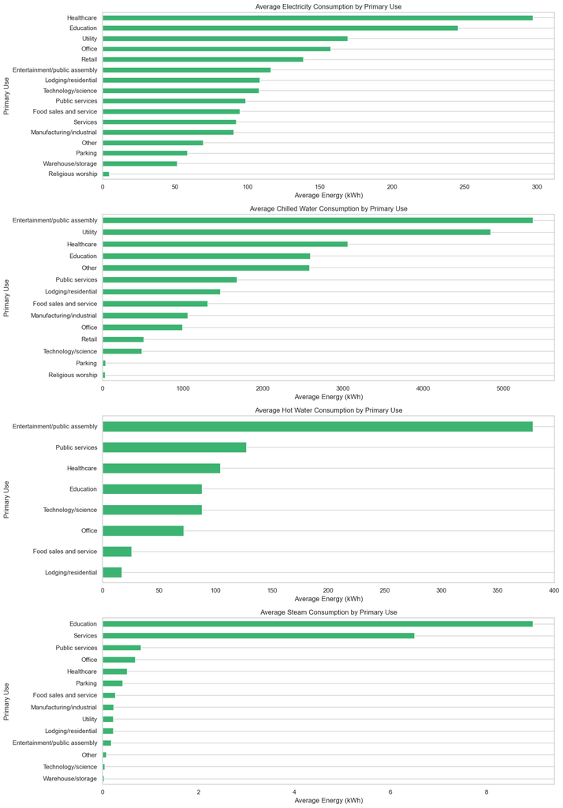

```python
# Get unique energy types
energy_types = df_train_combined["Energy_type_label"].unique()

# Set plot size for clarity
plt.figure(figsize=(14, 5 * len(energy_types)))

# Loop over each energy type and plot separately
for i, e_type in enumerate(energy_types, start=1):
    # Subset data
    df_subset = df_train_combined[df_train_combined["Energy_type_label"] == e_type]

    # Group and compute mean energy by primary use
    avg_by_use = (df_subset.groupby("primary_use")["Energy_kWh"].mean().sort_values())

    # Create subplot
    plt.subplot(len(energy_types), 1, i)
    avg_by_use.plot(kind="barh", color="mediumseagreen")
    plt.title(f"Average {e_type} Consumption by Primary Use")
    plt.xlabel("Average Energy (kWh)")
    plt.ylabel("Primary Use")
    plt.grid(axis='x')

plt.tight_layout()
plt.show()
```

#### **Interpretations:**

**1. Electricity**

- **Lowest consumption:** Religious worship (~4.6 kWh), Warehouse/storage, Parking — typically low-activity or low-demand uses.
- **Moderate consumption:** Retail, Office, Utility — commercial and service buildings with steady usage.
- **Highest consumption:** Education (245 kWh) and Healthcare (297 kWh) — likely due to intensive equipment and longer operating hours.

**2. Chilled Water**

- **Lowest consumption:** Religious worship (~28 kWh), Parking — minimal cooling demand.
- **Moderate consumption:** Office, Manufacturing/industrial (~1,000 kWh), Food sales and lodging show medium cooling needs.
- **Highest consumption:** Entertainment/public assembly (5,368 kWh), Utility (4,838 kWh), Education, Healthcare — large cooling loads due to building size, occupant density, or equipment.

**3. Hot Water**

- **Lowest consumption:** Lodging/residential (17 kWh), Food sales (25 kWh) — limited hot water demand.
- **Moderate consumption:** Office, Education, Technology/science (~70-90 kWh).
- **Highest consumption:** Entertainment/public assembly (381 kWh), Public services, Healthcare — likely reflecting showering, kitchen, or sanitation needs in these buildings.

**4. Steam**

- **Lowest consumption:** Warehouse/storage, Technology/science (<0.04 kWh) — minimal steam usage.
- **Moderate consumption:** Public services, Office (~0.7-0.8 kWh).
- **Higher consumption:** Education (9 kWh) and Services (6.5 kWh) — specialized processes, heating, or sterilization requiring steam.

**Summary:**

**Electricity** and **chilled water** show wide ranges reflecting operational intensity and building type, while **hot water** and **steam usage** tend to be lower overall but peak in specific building categories related to heating or process needs.

#### **B. Avg. Energy Consumption Distribution by Building Surface Size**

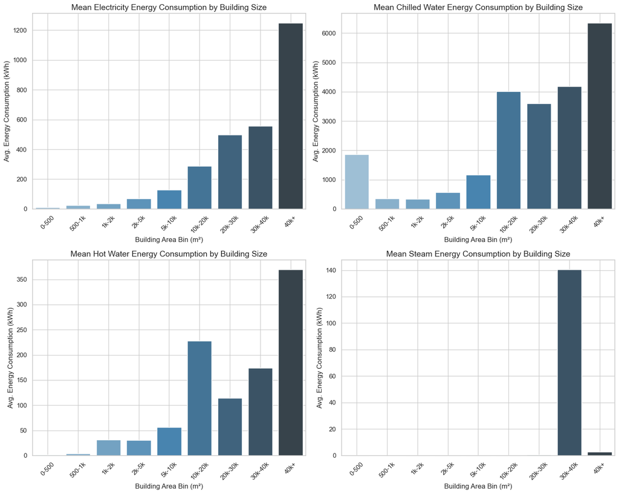

```python
# Get unique energy types
energy_types = df_train_combined["Energy_type_label"].unique()

# Subdivise the building surfaces into 9 bins
bins = [0, 500, 1000, 2000, 5000, 10000, 20000, 30000, 40000, np.inf]
labels = ['0-500', '500-1k', '1k-2k', '2k-5k', '5k-10k', '10k-20k','20k-30k', '30k-40k','40k+']

df_train_combined['size_bin'] = pd.cut(df_train_combined['square_meters'], bins=bins, labels=labels)

fig, axes = plt.subplots(2, 2, figsize=(15, 12))
axes = axes.flatten()

for i, etype in enumerate(energy_types):
    df_subset = df_train_combined[df_train_combined['Energy_type_label'] == etype]
    avg_energy = df_subset.groupby('size_bin')['Energy_kWh'].mean().reset_index()
    sns.barplot(
        data=avg_energy,
        x='size_bin',
        y='Energy_kWh',
        ax=axes[i],
        palette='Blues_d'
    )
    axes[i].set_title(f"Mean {etype} Energy Consumption by Building Size", fontsize=14)
    axes[i].set_xlabel("Building Area Bin (m²)")
    axes[i].set_ylabel("Avg. Energy Consumption (kWh)")
    axes[i].tick_params(axis='x', rotation=45)
    axes[i].grid(True)

plt.tight_layout()
plt.show()
```

#### **Interpretations:**

**1. Electricity**

| Size Bin | Avg. Consumption (kWh) | Interpretation |
| --- | --- | --- |
| 0–500 | 12.15 | Very low usage; likely minimal equipment and lighting. |
| 500–1k | 24.17 | Demand doubles—more appliances or small HVAC. |
| 1k–2k | 37.37 | Moderate increase; small offices or retail. |
| 2k–5k | 68.48 | Bigger systems in use; higher lighting/HVAC load. |
| 5k–10k | 127.76 | Operations expand—perhaps multi-floor buildings. |
| 10k–20k | 287.31 | Rapid increase—larger commercial facilities. |
| 20k–30k | 498.00 | Larger mixed-use or institutional buildings. |
| 30k–40k | 557.03 | Stable growth—potential efficiency gains. |
| 40k+ | 1249.26 | Sharp increase; data centers, malls, hospitals. |

- **Electricity consumption** scales almost exponentially with building size, peaking for very large structures.

**2. Chilled Water**

| Size Bin | Avg. Consumption (kWh) | Interpretation |
| --- | --- | --- |
| 0–500 | 1858.26 | Extremely high—likely outliers with heavy cooling. |
| 500–1k | 348.62 | Significant drop; more typical usage. |
| 1k–2k | 341.61 | Stable cooling demand. |
| 2k–5k | 562.61 | More occupants, greater cooling load. |
| 5k–10k | 1160.59 | Centralized HVAC systems in place. |
| 10k–20k | 4004.97 | High consumption; offices, universities. |
| 20k–30k | 3593.80 | Slight drop—efficient systems may play a role. |
| 30k–40k | 4178.15 | Large complex systems. |
| 40k+ | 6349.96 | Peak demand; intensive usage for cooling. |

- **Cooling needs** grow rapidly in large buildings, and outliers exist in the smallest bin—possibly special-use buildings.

**3. Hot Water**

| Size Bin | Avg. Consumption (kWh) | Interpretation |
| --- | --- | --- |
| 0–500 | 1.49 | Negligible; buildings may not have hot water. |
| 500–1k | 3.75 | Still low—likely basic facilities. |
| 1k–2k | 31.56 | Sharp jump—e.g., schools or kitchens. |
| 2k–5k | 30.30 | Consistent demand—institutional use. |
| 5k–10k | 56.11 | Growth with occupancy and facility needs. |
| 10k–20k | 227.41 | Hospitals, hotels, or dorms. |
| 20k–30k | 114.19 | Usage fluctuates by building type. |
| 30k–40k | 173.77 | Substantial heating systems. |
| 40k+ | 369.79 | Highest use—fully operational large sites. |

- **Hot water usage** is not linearly correlated to size—depends more on building function.

**4. Steam**

| Size Bin | Avg. Consumption (kWh) | Interpretation |
| --- | --- | --- |
| 0–500 | 0.18 | Very rare; few steam systems. |
| 500–1k | 0.02 | Negligible usage. |
| 1k–2k | 0.14 | Slightly present—legacy systems. |
| 2k–5k | 0.32 | Low use—basic heating. |
| 5k–10k | 0.18 | Unusual dip—possibly efficient buildings. |
| 10k–20k | 0.43 | Slow growth in demand. |
| 20k–30k | 0.55 | More consistent usage. |
| 30k–40k | 140.59 | Outlier spike—old hospitals/industrial plants. |
| 40k+ | 2.90 | Usage drops—likely modern systems replace steam. |

- **Steam usage** is mostly negligible—except for a sudden peak at 30k–40k, suggesting anomalies or legacy systems.

#### **C. Energy Density Distribution by Building Surface Size**

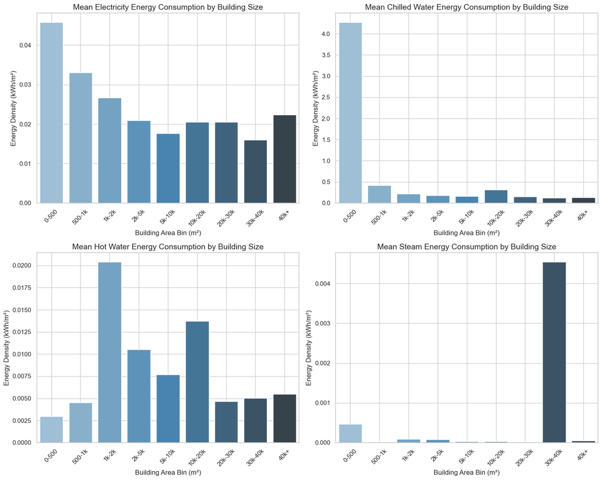

```python
# Get unique energy types
energy_types = df_train_combined["Energy_type_label"].unique()

# Subdivise the building surfaces into 9 bins
bins = [0, 500, 1000, 2000, 5000, 10000, 20000, 30000, 40000, np.inf]
labels = ['0-500', '500-1k', '1k-2k', '2k-5k', '5k-10k', '10k-20k','20k-30k', '30k-40k','40k+']

df_train_combined['size_bin'] = pd.cut(df_train_combined['square_meters'], bins=bins, labels=labels)

fig, axes = plt.subplots(2, 2, figsize=(15, 12))
axes = axes.flatten()

for i, etype in enumerate(energy_types):
    df_subset = df_train_combined[df_train_combined['Energy_type_label'] == etype]
    avg_energy = df_subset.groupby('size_bin')['energy_density_kwh_m2'].mean().reset_index()
    sns.barplot(
        data=avg_energy,
        x='size_bin',
        y='energy_density_kwh_m2',
        ax=axes[i],
        palette='Blues_d'
    )
    axes[i].set_title(f"Mean {etype} Energy Consumption by Building Size", fontsize=14)
    axes[i].set_xlabel("Building Area Bin (m²)")
    axes[i].set_ylabel("Energy Density (kWh/m²)")
    axes[i].tick_params(axis='x', rotation=45)
    axes[i].grid(True)

plt.tight_layout()
plt.show()
```

#### **Interpretations:**

**2. Hot Water**

**3. Steam**

- **Trend:** Extremely low across all sizes, with a sudden spike at 30k–40k m².
- **Interpretation:** Steam is used rarely, possibly in specialized industrial or institutional buildings. The spike may reflect outlier buildings with niche operational needs.

**5. General Insights**

- Energy density generally decreases with size, showing efficiency gains in larger buildings.
- Exceptions (spikes) suggest that building function (not just size) has a strong impact.
- Further investigation into primary_use and building types in small size bins may reveal why certain energy types peak disproportionately.

**While average energy consumption generally increases with building surface area (larger buildings consume more total energy), energy density (kWh/m²) offers a more insightful measure of efficiency. It reveals how intensively energy is used per square meter, regardless of size. For instance, a small data center may consume less total energy than a university campus but exhibit a much higher energy density due to concentrated equipment loads. In contrast, warehouses often have low energy density despite their large size, indicating lower operational intensity.**

#### **D. Energy Density (kWh/m²) by Primary Use of Buildings**

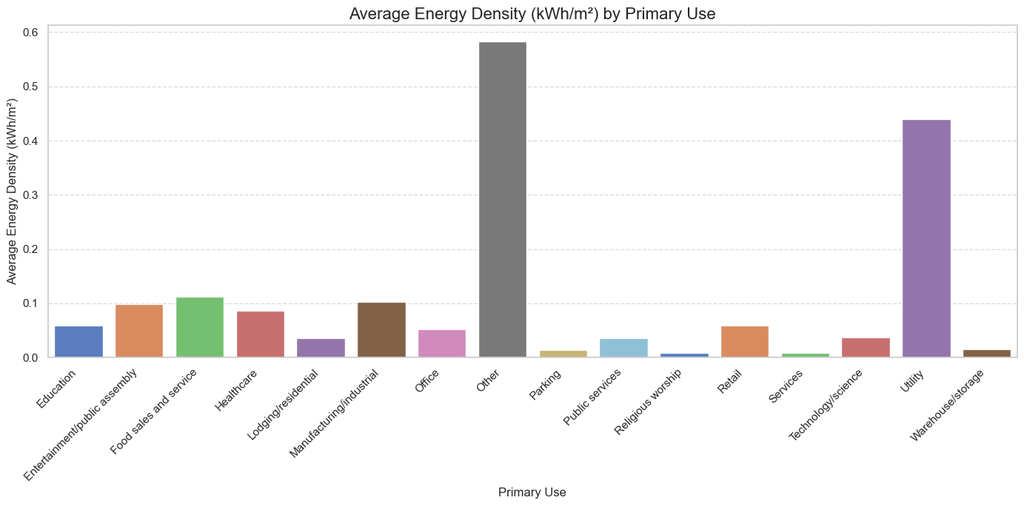

```python
# Calculate average energy density by primary use
avg_energy_density = df_train_combined.groupby('primary_use')['energy_density_kwh_m2'].mean().reset_index()

plt.figure(figsize=(14, 7))
sns.barplot(
    data=avg_energy_density,
    x='primary_use',
    y='energy_density_kwh_m2',
    palette='muted'
)
plt.title("Average Energy Density (kWh/m²) by Primary Use", fontsize=16)
plt.xlabel("Primary Use", fontsize=12)
plt.ylabel("Average Energy Density (kWh/m²)", fontsize=12)
plt.xticks(rotation=45, ha='right')
plt.grid(True, axis='y', linestyle='--', alpha=0.7)
plt.tight_layout()
plt.show()
```

#### **Interpretations:**

| Primary Use | Energy Density (kWh/m²) | Interpretation |
| --- | --- | --- |
| Education | 0.058 | Moderate energy density reflecting typical use of classrooms and labs with lighting and HVAC. |
| Entertainment/public assembly | 0.098 | Higher energy density due to lighting, sound, and HVAC demands during events. |
| Food sales and service | 0.112 | Elevated energy intensity for cooking equipment, refrigeration, and customer spaces. |
| Healthcare | 0.086 | Moderate to high energy density; medical equipment and climate control increase usage. |
| Lodging/residential | 0.036 | Lower density; residential buildings typically use less energy per area compared to commercial. |
| Manufacturing/industrial | 0.102 | High energy density due to machinery and process operations within limited space. |
| Office | 0.052 | Moderate density driven by lighting, computers, and HVAC systems. |
| Other | 0.583 | Very high density likely includes specialized or mixed-use buildings with intensive operations. |
| Parking | 0.014 | Very low density; minimal energy use mainly for lighting and ventilation. |
| Public services | 0.035 | Low density, reflecting government buildings or community centers with moderate use. |
| Religious worship | 0.008 | Lowest density, minimal energy demands mostly for lighting and HVAC during services. |
| Retail | 0.059 | Moderate energy density typical for lighting and refrigeration in shops. |
| Services | 0.008 | Very low density, likely small-scale or low-energy service facilities. |
| Technology/science | 0.037 | Low to moderate energy density; labs and tech spaces with specialized equipment. |
| Utility | 0.439 | High density, consistent with energy-intensive utility operations and equipment. |
| Warehouse/storage | 0.015 | Very low density due to large spaces with limited energy-consuming equipment or lighting. |

**Summary:**

- **Buildings with intensive equipment or specific functions (e.g., Food service, Manufacturing, Utility) tend to have higher energy density.**
- **Large open spaces or minimal usage buildings (Parking, Warehouse, Religious worship) show very low energy density.**
- **“Other” category’s very high energy density suggests it contains specialized or mixed-use buildings with high energy demands.**
- **Commercial and institutional types like Education, Healthcare, and Offices have moderate, expected densities reflecting typical operational loads.**

### **4. Weather Impact on Building Energy Consumptions**

**Goal:** To understand how external weather conditions influence the energy consumption patterns of buildings. Weather variables such as air temperature, dew point temperature, wind speed, and humidity can significantly affect heating, cooling, and ventilation demands, impacting total energy usage.

#### **A. Exploratory Scatterplots**

**Purpose:** Visualize the relationships between key weather variables and energy consumption to identify trends, thresholds, or nonlinear patterns.

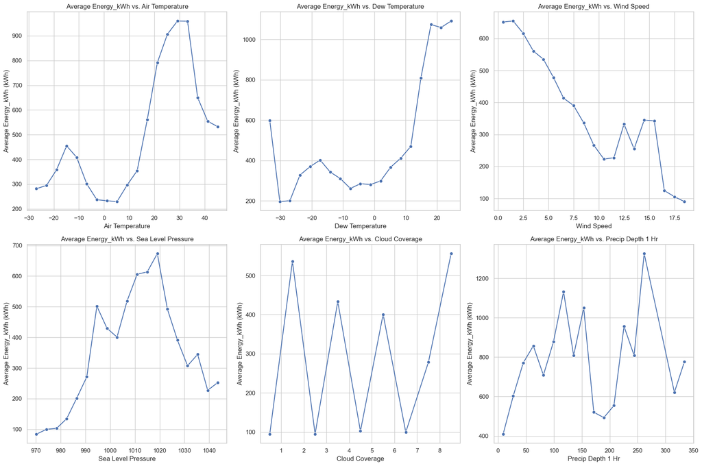

```python
# List of the weather variables
weather_vars = ["air_temperature", "dew_temperature", "wind_speed", "sea_level_pressure", "cloud_coverage", "precip_depth_1_hr"]
energy_var = "Energy_kWh"

plt.figure(figsize=(18, 12))

for i, var in enumerate(weather_vars, 1):
    plt.subplot(2, 3, i)

    # Create bins for the weather variable (adjust bins or method as needed)
    if var == "cloud_coverage":  # cloud_coverage might be categorical or limited range
        bins = np.arange(df_train_combined[var].min(), df_train_combined[var].max() + 1)
    else:
        bins = np.linspace(df_train_combined[var].min(), df_train_combined[var].max(), 20)

    df_train_combined["bin"] = pd.cut(df_train_combined[var], bins=bins)

    # Calculate mean energy consumption per bin
    avg_energy = df_train_combined.groupby("bin")[energy_var].mean().reset_index()

    # Use midpoints of bins for plotting on x-axis
    avg_energy["bin_mid"] = avg_energy["bin"].apply(lambda x: x.mid if pd.notnull(x) else np.nan)

    sns.lineplot(data=avg_energy, x="bin_mid", y=energy_var, marker="o")
    plt.title(f"Average {energy_var} vs. {var.replace('_', ' ').title()}")
    plt.xlabel(var.replace('_', ' ').title())
    plt.ylabel(f"Average {energy_var} (kWh)")
    plt.grid(True)

plt.tight_layout()
plt.show()

# Remove temporary 'bin' column
df_train_combined.drop(columns=["bin"], inplace=True)
```

#### **Interpretations:**

**1. Air Temperature**

Energy consumption increases significantly with rising air temperature, starting moderately low at very cold temperatures (281 kWh at -28.9 to -24.9°C), then rising sharply above 15°C, peaking around 30–35°C (960 kWh). **This suggests strong cooling loads during warmer periods, driving up energy use.**

**2. Dew Temperature**

Energy use is high at extreme cold dew points (599 kWh at -35°C), drops sharply in moderate cold, then steadily rises from moderate dew points (310 kWh at -12°C) to very high dew points (~1091 kWh at 22–26°C). **This again indicates HVAC and cooling demand increasing with warmer, more humid air.**

**5. Cloud Coverage**

Energy use fluctuates widely with cloud coverage, showing spikes at some intervals (e.g., 536 kWh at 1–2 oktas, 556 kWh at 8–9 oktas) and lows at others (95 kWh at 0–1 and 2–3 oktas). **This could reflect the complex interplay of solar gain, lighting needs, and HVAC operation.**

**6. Precipitation Depth (1 hr)**

Energy consumption increases with precipitation depth, rising from 409 kWh at minimal rain to peaks above 1300 kWh at heavier rainfall (252–271 mm). **Wet weather likely increases heating or lighting demand and may reduce passive cooling effects.**

**Summary:**

Energy consumption is strongly affected by weather conditions, especially temperature and humidity, with cooling loads driving high energy use at warmer and more humid conditions. Wind speed appears to mitigate energy consumption possibly through natural ventilation. Cloud coverage and precipitation also show notable influence, likely due to their effects on solar gain and indoor climate control requirements.

#### **B. Average Energy Usage Across Air Temperature**

**Purpose:** Aggregate energy consumption by discrete temperature intervals to smooth out noise and highlight systematic patterns.

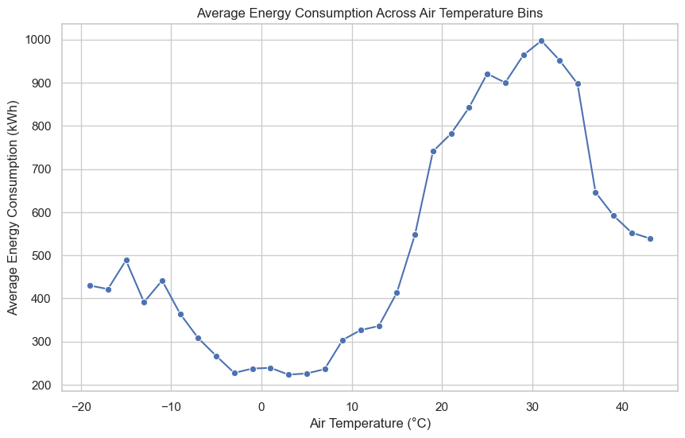

```python
# Create temperature bins
temp_bins = pd.cut(df_train_combined["air_temperature"], bins=range(-20, 45, 2))

# Group by bins and calculate mean energy consumption
energy_temp_bin = df_train_combined.groupby(temp_bins)["Energy_kWh"].mean().reset_index()

# energy_temp_bin['air_temperature'] currently contains Interval objects, rename for clarity
energy_temp_bin.rename(columns={"air_temperature": "temp_bin"}, inplace=True)

# Calculate midpoint of each bin interval for plotting
energy_temp_bin['bin_midpoint'] = energy_temp_bin['temp_bin'].apply(lambda x: (x.left + x.right) / 2)

# Plot using bin_midpoint instead of Interval object
plt.figure(figsize=(10, 6))
sns.lineplot(data=energy_temp_bin, x="bin_midpoint", y="Energy_kWh", marker='o')
plt.title("Average Energy Consumption Across Air Temperature Bins")
plt.xlabel("Air Temperature (°C)")
plt.ylabel("Average Energy Consumption (kWh)")
plt.grid(True)
plt.show()
```

#### **Interpretation: Average Energy Consumption vs. Air Temperature**

| Temperature (°C) | Average Energy Consumption (kWh) | Interpretation |
| --- | --- | --- |
| -20 to -18 | 430.0 | At very low temperatures, buildings consume a high amount of energy — likely due to heating systems working intensively. |
| -18 to -14 | ~421–488 | Energy use remains consistently high in cold conditions as heating demand persists. |
| -12 to -6 | ~442 → 308 | A gradual drop in energy use suggests slightly milder cold requires less heating. |
| -6 to 0 | ~267 → 238 | Energy use dips further, likely as external temperatures near freezing and building insulation reduces heating needs. |
| 0 to 6 | ~239 → 226 | Around mild cold, energy consumption is at its lowest, possibly due to minimal heating or cooling needs. |
| 6 to 14 | ~236 → 336 | Slight uptick suggests some early cooling or variable occupancy/activity patterns. |
| 14 to 18 | ~414 → 547 | A clear rise begins, likely due to air conditioning or ventilation loads. |
| 18 to 26 | ~741 → 920 | A sharp increase in energy demand: higher temperatures trigger extensive cooling needs in buildings. |
| 26 to 32 | ~900 → 997 | Peak energy consumption, strongly correlated with maximum cooling load (HVAC). |
| 32 to 36 | ~952 → 897 | Slight decrease might reflect system limits, building thermal saturation, or reduced occupancy in extreme heat. |
| 36 to 44 | ~646 → 539 | A decline in energy use in extremely high temperatures — possibly due to load shedding, lower occupancy, or efficient cooling systems kicking in. |

**Key Takeaways:**

- **Colder temperatures (below 0°C) show moderate to high energy usage driven mainly by heating.**
- **Temperatures around 0–10°C are associated with lowest average energy usage — a thermal comfort zone where neither heating nor cooling is heavily required.**
- **Warm to hot temperatures (18–32°C) result in peak energy demands, likely driven by HVAC systems battling heat loads.**
- **Extremely hot weather (above 36°C) sees a drop in average usage, which may reflect operational constraints, reduced activity, or better demand-side management.**

#### **C. Correlation Heatmap Including Weather Variables**

**Purpose:** Quantify linear relationships between energy consumption and weather variables alongside building and time features.

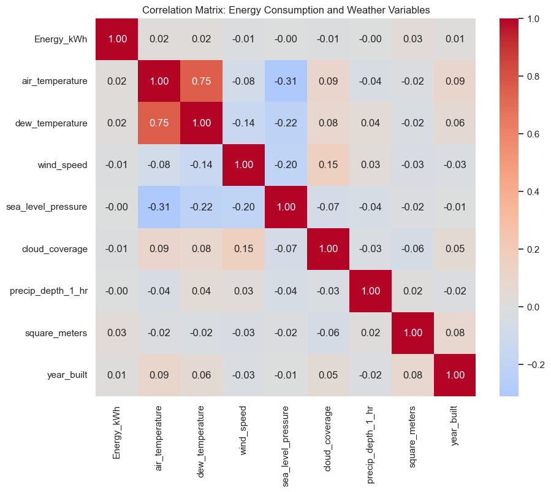

```python
# Select numerical columns relevant to energy and weather
num_cols = ["Energy_kWh", "air_temperature", "dew_temperature", "wind_speed", "sea_level_pressure", "cloud_coverage", "precip_depth_1_hr",
                                    "square_meters", "year_built"]

corr_matrix = df_train_combined[num_cols].corr()

plt.figure(figsize=(10, 8))
sns.heatmap(corr_matrix, annot=True, fmt=".2f", cmap="coolwarm", center=0)
plt.title("Correlation Matrix: Energy Consumption and Weather Variables")
plt.show()
```

#### **Interpretation**

- **Energy Consumption (Energy_KWh) has very weak correlations with all other variables**. The highest is with:
  - **square_meters (0.034):** Slight positive correlation — larger buildings use slightly more energy.
  - **dew_temperature and air_temperature (~0.02):** Slight link, possibly reflecting HVAC usage in response to weather.
  - Overall, no strong linear predictors of energy consumption in this matrix.
- **air_temperature** and **dew_temperature:** Strong positive correlation (0.75), as expected due to shared climatic influence.
- **wind_speed** shows weak negative correlations with most variables but moderately correlates with **cloud_coverage (0.15)**, possibly indicating turbulent weather systems.
- **sea_level_pressure** negatively correlates with **air_temperature (-0.31)**, consistent with pressure drop during warmer or stormy weather.
- **year_built** and **square_meters** show weak positive correlations with each other and some weather variables, suggesting mild trends (e.g., newer buildings might be larger or differently located).

**Summary:**

- **No variable in the matrix is a strong standalone predictor of energy use.**
- **Temperature and humidity may influence usage patterns but likely non-linearly.**
- **Consider using nonlinear models or feature interactions for better predictive insights.**

### **5. General Conclusion: Exploratory Data Analysis (EDA) on Building Energy Consumption**

This exploratory analysis provided key insights into the **energy consumption patterns** of various building types, considering **weather conditions** and **structural features**. The goal was to identify drivers of high energy use and opportunities for improving efficiency.

#### **A. Energy Density by Primary Use**

| Primary Use | Energy Density (kWh/m²) | Insight |
| --- | --- | --- |
| Other | 0.583 | Exceptionally high use — likely due to specialized operations. |
| Utility | 0.439 | High energy intensity from continuous or heavy-duty systems. |
| Food Sales and Service | 0.112 | Elevated use due to long operating hours and equipment. |
| Entertainment/Public Assembly | 0.098 | High footfall and lighting/ventilation needs drive energy use. |
| Manufacturing/Industrial | 0.102 | Energy-intensive machinery and systems involved. |
| Religious Worship, Parking, etc. | < 0.02 | Minimal use — consistent with intermittent activity. |

**Conclusion:** Building function is a primary driver of energy use, and strategies for efficiency must be tailored to usage profiles.

#### **2. Energy Consumption Across Temperature Bins**

| Temperature (°C) | Avg Energy (kWh) | Interpretation |
| --- | --- | --- |
| -20 to -18 | 430 | High heating demand in extreme cold. |
| -18 to -6 | ~420–308 | Gradual drop as cold moderates. |
| -6 to 6 | ~267–226 | Lowest usage: minimal HVAC needed. |
| 6 to 14 | ~236–336 | Slight rise — early cooling or increased building use. |
| 14 to 26 | ~414–920 | Sharp rise from cooling demand. |
| 26 to 32 | ~900–997 | Peak usage due to HVAC loads. |
| 32 to 44 | ~952–539 | Slight drop — saturation, efficient systems, or occupancy drop. |

#### **3. Correlation Matrix Insights**

| Variable | Correlation with Energy_KWh |
| --- | --- |
| Air Temperature | +0.019 |
| Dew Temperature | +0.021 |
| Wind Speed | -0.008 |
| Sea Level Pressure | -0.002 |
| Cloud Coverage | -0.008 |
| Precipitation (1hr) | ~0.000 |
| Square Meters | +0.034 |
| Year Built | +0.014 |

**Conclusion:** Weak linear relationships across all weather and building variables suggest energy use is driven by **nonlinear** or **interacting effects**, not easily captured by correlation alone.

#### **Overall Insight**

Energy performance is shaped by a mix of:

- **Primary Use Type**
- **Ambient Weather Conditions**
- **Structural and Operational Factors**

**Recommendations:**

- Use **weather-adaptive systems** for temperature control.
- Implement **targeted efficiency strategies** per building type.
- Apply **nonlinear modeling (e.g. ML)** to better capture the real drivers of energy usage.

***Next Steps:* Consider feature engineering and building predictive models using these findings as a foundation.**

## **Filter the data by energy type**

To ensure accurate modeling and meaningful predictions, it is essential to treat each energy type separately in the analysis. Different energy types—such as **electricity**, **steam**, **hot water**, and **chilled water**—exhibit distinct consumption patterns, seasonal behaviors, and influencing factors. Combining them in a single model may obscure important relationships and reduce predictive performance. By segmenting the dataset by energy type and building separate models, we can better capture the unique characteristics of each energy system and enhance the overall accuracy and interpretability of our results.

#### **Generate a train dataframe for each energy type: electricity, steam, chilled water and hot water**

```python
# Dataframe for training electricity consumption
electricity_train = df_train_combined[df_train_combined['Energy_type'] == 0]
# Checking the shape of electricity_train dataset
electricity_train.shape
```

```
(12060910, 33)
```

```python
# Build a dataset for chilled_water consumption
chilled_water_train = df_train_combined[df_train_combined['Energy_type'] == 1]
# Checking the shape of chilled_water_train dataset
chilled_water_train.shape
```

```
(4182440, 33)
```

```python
# Build a dataset for steam consumption
steam_train = df_train_combined[df_train_combined['Energy_type'] == 2]
# Checking the shape of steam_train dataset
steam_train.shape
```

```
(2708713, 33)
```

```python
# Dataframe for training hot_water consumption
hot_water_train = df_train_combined[df_train_combined['Energy_type'] == 3]
# Checking the shape of hot_water_train dataset
hot_water_train.shape
```

```
(1264037, 33)
```

#### **Save the dataframe datasets to csv files in local device**

```python
# save electricity database as csv file
electricity_train.to_csv("C:/Disc D/Projects to publish/Projects to do/Energy Efficiency Analytics in Buildings/electricity_train.csv", index=False)
```

```python
# save chilled water database as csv file
chilled_water_train.to_csv("C:/Disc D/Projects to publish/Projects to do/Energy Efficiency Analytics in Buildings/chilled_water_train.csv", index=False)
```

```python
# save hot water database as csv file
hot_water_train.to_csv("C:/Disc D/Projects to publish/Projects to do/Energy Efficiency Analytics in Buildings/hot_water_train.csv", index=False)
```

```python
# save steam database as csv file
steam_train.to_csv("C:/Disc D/Projects to publish/Projects to do/Energy Efficiency Analytics in Buildings/steam_train.csv", index=False)
```

#### **Load the electricity dataset (csv file) from the local device**

```python
# Load database
electricity_train = pd.read_csv("C:/Disc D/Projects to publish/Projects to do/Energy Efficiency Analytics in Buildings/electricity_train.csv")
```

## **High-value interaction features**

We can (and often should) consider interaction features—especially in complex domains like building energy prediction where variables interact in non-linear, seasonal, and context-dependent ways.

The current feature set is rich and well-structured, with time, weather, building characteristics, and categorical encodings. But interactions can help our model discover compound effects that may not be obvious with individual variables.

To seamlessly integrate the interaction features into the preprocessing pipeline — cleanly and modularly — while keeping things memory-safe and efficient even with large datasets:

```python
def add_interaction_features(df):
    # Group columns
    weather_vars = ['air_temperature', 'cloud_coverage', 'dew_temperature', 'precip_depth_1_hr',
                    'sea_level_pressure', 'wind_direction', 'wind_speed']
    time_vars = ['is_weekend', 'is_work_hour', 'hour_sin', 'hour_cos', 'dayofweek_sin',
                 'dayofweek_cos', 'month_sin', 'month_cos']
    building_vars = ['square_meters', 'building_age', 'is_modern_building']

    # Auto-detect dummies for primary_use, season, site_id
    primary_uses = [col for col in df.columns if col.startswith('primary_use_')]
    seasons = [col for col in df.columns if col.startswith('season_')]

    # Weather × Time
    for w in weather_vars:
        for t in ['is_work_hour', 'is_weekend', 'hour_cos', 'month_cos']:
            if w in df.columns and t in df.columns:
                df[f'{w}_x_{t}'] = df[w] * df[t]

    # Building × Time
    for b in building_vars:
        for t in ['is_work_hour', 'is_weekend', 'hour_cos']:
            if b in df.columns and t in df.columns:
                df[f'{b}_x_{t}'] = df[b] * df[t]

    # Weather × Building
    for w in ['air_temperature', 'dew_temperature', 'wind_speed']:
        for b in ['square_meters', 'is_modern_building']:
            if w in df.columns and b in df.columns:
                df[f'{w}_x_{b}'] = df[w] * df[b]

    # Primary Use × Time
    for p in primary_uses:
        for t in ['is_work_hour', 'dayofweek_cos', 'hour_cos']:
            if p in df.columns and t in df.columns:
                df[f'{p}_x_{t}'] = df[p] * df[t]

    # Primary Use × Season
    for p in primary_uses:
        for s in seasons:
            if p in df.columns and s in df.columns:
                df[f'{p}_x_{s}'] = df[p] * df[s]

    return df
```

By creating targeted interactions, we allow our model to:

- **Discover subtle nonlinearities more easily**.
- **Reduce reliance on deep trees to learn them**.
- **Improve generalization and interpretability**.
- **The target variable to fit is: `Energy_kWh` or `energy_density_kwh_m2`.**

## **Modelling of energy density in buildings**

To better understand the drivers of energy use in buildings, this section focuses on developing predictive models for different types of energy consumption separately—namely electricity, chilled water, steam, and hot water. By treating each energy type individually, we can capture the specific usage patterns, weather dependencies, and operational characteristics unique to each system. This granular approach improves both interpretability and model accuracy, providing actionable insights for energy optimization and sustainability planning.

## **1. Electricity**

### **Feature Engineering & data preparation**

**Enhance the dataset by adding useful dummied features and interaction features**

#### **a. Creating dummy variables for `site_id`, `primary_use` and `season` features**

```python
# Generate dummy variables and concatenate
electricity_train_dummy = electricity_train.copy()
for col in ["site_id", "primary_use", "season"]:
    dummies = pd.get_dummies(electricity_train_dummy[col], prefix=col, drop_first=True)
    electricity_train_dummy = pd.concat([electricity_train_dummy, dummies], axis=1)
```

```python
electricity_train_dummy.head(2)
```

|  | building_id | Energy_type | timestamp | meter_reading | site_id | primary_use | square_feet | year_built | air_temperature | cloud_coverage | dew_temperature | precip_depth_1_hr | sea_level_pressure | wind_direction | wind_speed | square_meters | Energy_kWh | hour | dayofweek | month | is_weekend | is_work_hour | season | hour_sin | hour_cos | dayofweek_sin | dayofweek_cos | month_sin | month_cos | … |
| --- | --- | --- | --- | --- | --- | --- | --- | --- | --- | --- | --- | --- | --- | --- | --- | --- | --- | --- | --- | --- | --- | --- | --- | --- | --- | --- | --- | --- | --- | --- |
| 0 | 0 | 0 | 2016-01-01 | 0.0 | 0 | Education | 7432 | 2008.0 | 25.0 | 6.0 | 20.0 | 0.0 | 1019.7 | 0.0 | 0.0 | 690.455096 | 0.0 | 0 | 4 | 1 | 0 | 0 | Winter | 0.0 | 1.0 | -0.433884 | -0.900969 | 0.5 | 0.866025 | … |
| 1 | 1 | 0 | 2016-01-01 | 0.0 | 0 | Education | 2720 | 2004.0 | 25.0 | 6.0 | 20.0 | 0.0 | 1019.7 | 0.0 | 0.0 | 252.696160 | 0.0 | 0 | 4 | 1 | 0 | 0 | Winter | 0.0 | 1.0 | -0.433884 | -0.900969 | 0.5 | 0.866025 | … |

```python
electricity_train_dummy.shape
```

```
(12060910, 66)
```

- **Convert boolean values (True/False) to binary integers (1/0).**

```python
bool_cols = ['site_id_1','site_id_2','site_id_3','site_id_4', 'site_id_5','site_id_6',
             'site_id_7', 'site_id_8','site_id_9','site_id_10','site_id_11','site_id_12','site_id_13',
             'site_id_14','site_id_15', 'primary_use_Entertainment/public assembly','primary_use_Food sales and service',
             'primary_use_Healthcare', 'primary_use_Lodging/residential','primary_use_Manufacturing/industrial','primary_use_Office',
             'primary_use_Other', 'primary_use_Parking','primary_use_Public services','primary_use_Religious worship','primary_use_Retail',
             'primary_use_Services','primary_use_Technology/science','primary_use_Utility','primary_use_Warehouse/storage',
             'season_Spring','season_Summer','season_Winter']

electricity_train_dummy[bool_cols] = electricity_train_dummy[bool_cols].astype(int)
```

```python
electricity_train_dummy.head(2)
```

|  | building_id | Energy_type | timestamp | meter_reading | site_id | primary_use | square_feet | year_built | air_temperature | cloud_coverage | dew_temperature | precip_depth_1_hr | sea_level_pressure | wind_direction | wind_speed | square_meters | Energy_kWh | hour | dayofweek | month | is_weekend | is_work_hour | season | hour_sin | hour_cos | dayofweek_sin | dayofweek_cos | month_sin | month_cos | … |
| --- | --- | --- | --- | --- | --- | --- | --- | --- | --- | --- | --- | --- | --- | --- | --- | --- | --- | --- | --- | --- | --- | --- | --- | --- | --- | --- | --- | --- | --- | --- |
| 0 | 0 | 0 | 2016-01-01 | 0.0 | 0 | Education | 7432 | 2008.0 | 25.0 | 6.0 | 20.0 | 0.0 | 1019.7 | 0.0 | 0.0 | 690.455096 | 0.0 | 0 | 4 | 1 | 0 | 0 | Winter | 0.0 | 1.0 | -0.433884 | -0.900969 | 0.5 | 0.866025 | … |
| 1 | 1 | 0 | 2016-01-01 | 0.0 | 0 | Education | 2720 | 2004.0 | 25.0 | 6.0 | 20.0 | 0.0 | 1019.7 | 0.0 | 0.0 | 252.696160 | 0.0 | 0 | 4 | 1 | 0 | 0 | Winter | 0.0 | 1.0 | -0.433884 | -0.900969 | 0.5 | 0.866025 | … |

#### **b. Sample a data subset of 5M rows**

- Working with **full 12M rows** is not possible **due to memory**.
- We have now to sample a dataset of **5M rows** to train and validate the model.
- This is a very efficient and practical tradeoff between performance and memory constraints.
- **Sample 5 million rows from electricity_train_dummy, stratified by multiple features (multi-key sampling) and preserve distribution.**

```python
# Step 1: Create binned or categorical columns for stratification
df = electricity_train_dummy

# Example binning for a continuous variable (e.g., temperature)
df["air_temp_bin"] = pd.qcut(df["air_temperature"], q=20, duplicates='drop')

# Create a composite stratification key
df["strata_key"] = df["building_id"].astype(str) + "_" + \
                   df["primary_use"].astype(str) + "_" + \
                   df["site_id"].astype(str) + "_" + \
                   df["air_temp_bin"].astype(str)

# Step 2: Group by the composite key and sample proportionally
frac = 5_000_000 / len(df)

sampled_df = df.groupby("strata_key", group_keys=False).apply(
    lambda x: x.sample(frac=min(1.0, frac), random_state=42)
).reset_index(drop=True)
```

#### **c. Add the interaction features**

```python
# Add interaction features
sampled_df = add_interaction_features(sampled_df)
```

```python
sampled_df.shape
```

```
(4999572, 201)
```

The sample data is composed of 4,999,572 rows and 201 features. Some unuseful features have to be dropped.

```python
sampled_df.head(2)
```

|  | building_id | Energy_type | timestamp | meter_reading | site_id | primary_use | square_feet | year_built | air_temperature | cloud_coverage | dew_temperature | precip_depth_1_hr | sea_level_pressure | wind_direction | wind_speed | square_meters | Energy_kWh | hour | dayofweek | month | is_weekend | is_work_hour | season | hour_sin | hour_cos | dayofweek_sin | dayofweek_cos | month_sin | month_cos | … |
| --- | --- | --- | --- | --- | --- | --- | --- | --- | --- | --- | --- | --- | --- | --- | --- | --- | --- | --- | --- | --- | --- | --- | --- | --- | --- | --- | --- | --- | --- | --- |
| 0 | 0 | 0 | 2016-01-24 11:00:00 | 0.0 | 0 | Education | 7432 | 2008.0 | 2.2 | 0.0 | -3.3 | 0.0 | 1020.5 | 310.0 | 4.1 | 690.455096 | 0.0 | 11 | 6 | 1 | 1 | 0 | Winter | 0.258819 | -0.965926 | -0.781831 | 0.62349 | 0.5 | 0.866025 | … |
| 1 | 0 | 0 | 2016-01-24 13:00:00 | 0.0 | 0 | Education | 7432 | 2008.0 | 1.7 | 0.0 | -3.9 | 0.0 | 1021.9 | 320.0 | 4.1 | 690.455096 | 0.0 | 13 | 6 | 1 | 1 | 0 | Winter | -0.258819 | -0.965926 | -0.781831 | 0.62349 | 0.5 | 0.866025 | … |

#### **d. Split the dataset into train and test subsets**

```python
# List of features to drop
fet_to_drop2 = ['Energy_type', 'timestamp', 'meter_reading', 'site_id', 'primary_use', 'square_feet', 'year_built', 'Energy_kWh',
                'hour', 'dayofweek', 'month', 'era_bin', 'season', 'energy_density_kwh_m2', 'air_temp_bin', 'strata_key']

# train dataset
X_elec = sampled_df.drop(columns=[col for col in fet_to_drop2 if col in sampled_df.columns])
y_elec = sampled_df['energy_density_kwh_m2']
```

```python
# We split two dataframes with inputs and targets, each into a train and test dataframe, and store them in variables.
X_elec_train, X_elec_test, y_elec_train, y_elec_test = train_test_split(X_elec, y_elec, test_size=0.3, random_state=42, shuffle=True)
```

```python
# Shape of train and test data subsets
print('Train subset shape: ', X_elec_train.shape)
print('Test subset shape: ', X_elec_test.shape)
```

```
Train subset shape:  (3499700, 185)
Test subset shape:  (1499872, 185)
```

- **The train dataset is composed of 3,499,700 rows and 185 independant features**.
- **The test dataset is composed of 1,499,872 rows and 185 independant features**.

#### **e. Checking for Outliers**

- **Distribution Plot**

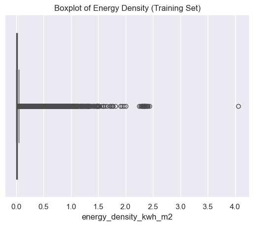

```python
# Example for Energy_kWh
sns.boxplot(x = y_elec_train)
plt.title("Boxplot of Energy Density (Training Set)")
plt.show()
```

As can be observed on the figure, there are a lot of outliers.

- **IQR method**

```python
Q1 = y_elec_train.quantile(0.25)
Q3 = y_elec_train.quantile(0.75)
IQR = Q3 - Q1

outlier_mask = (y_elec_train < (Q1 - 1.5 * IQR)) | (y_elec_train > (Q3 + 1.5 * IQR))
print(f"Outliers: {outlier_mask.sum()} / {len(y_elec_train)}")
```

```
Outliers: 297163 / 3499700
```

For energy density, we have about 297,163 outliers out of 3,499,700 rows — that's only ~8.5% of our data.

### **LGBMRegressor Model**

#### **a. Function to train the model**

```python
# import the libraries
from lightgbm import LGBMRegressor
from sklearn.metrics import mean_squared_error, mean_absolute_error, r2_score, median_absolute_error

# LightGBM Model Training Function
def train_lgbm(X_train, y_train):
    model = LGBMRegressor(
        objective='regression',
        n_estimators=1000,
        learning_rate=0.05,
        max_depth=-1,
        num_leaves=31,
        random_state=42
    )
    model.fit(X_train, y_train)
    return model
```

#### **b. Functions to evaluate the model**

```python
# SMAPE
def smape(y_true, y_pred):
    return 100 * np.mean(2 * np.abs(y_pred - y_true) / (np.abs(y_pred) + np.abs(y_true)))

# Evaluation Function
def evaluate_model(name, y_true, y_pred):
    print(f"--- {name} ---")
    print("RMSE:", mean_squared_error(y_true, y_pred, squared=False))
    print("MAE:", mean_absolute_error(y_true, y_pred))
    print("Median AE:", median_absolute_error(y_true, y_pred))
    print("R²:", r2_score(y_true, y_pred))
    print("SMAPE: {:.2f} %".format(smape(y_true, y_pred)))
    print()
```

#### **c. IQR Outlier Handling**

Train the model, with "Energy Density" as target variable, on:

- **Original data**
- **Cleaned data (IQR-filtered)**
- **Clipped data (IQR-capped)**

```python
# ----- 1. Clip feature values -----
def iqr_clip_columns_inplace(df, cols=None, iqr_multiplier=1.5):
    if cols is None:
        cols = df.select_dtypes(include=np.number).columns
    for col in cols:
        q1 = df[col].quantile(0.25)
        q3 = df[col].quantile(0.75)
        iqr = q3 - q1
        lower = q1 - iqr_multiplier * iqr
        upper = q3 + iqr_multiplier * iqr
        df[col] = df[col].clip(lower=lower, upper=upper)
    return df

# Apply feature clipping
X_capped = X_elec_train.copy()
iqr_clip_columns_inplace(X_capped)

# ----- 2. Compute target variable bounds -----
Q1_y = y_elec_train.quantile(0.25)
Q3_y = y_elec_train.quantile(0.75)
IQR_y = Q3_y - Q1_y
lower_bound = Q1_y - 1.5 * IQR_y
upper_bound = Q3_y + 1.5 * IQR_y

# ----- 3. Identify outliers in target -----
outlier_mask = (y_elec_train < lower_bound) | (y_elec_train > upper_bound)
print(f"Outliers in target: {outlier_mask.sum()} / {len(y_elec_train)}")

# ----- Option A: Clip the target variable -----
y_capped = y_elec_train.clip(lower=lower_bound, upper=upper_bound)

# ----- Option B: Filter out outlier rows completely -----
X_filtered = X_capped[~outlier_mask]
y_filtered = y_elec_train[~outlier_mask]
```

```
Outliers in target: 297163 / 3499700
```

```python
X_elec_train.shape
```

```
(3499700, 185)
```

```python
X_filtered.shape
```

```
(3202537, 185)
```

**The dataset without outliers is composed by 3,202,537 rows.**

#### **d. Train Models and Compare**

```python
# Original data
model_orig = train_lgbm(X_elec_train, y_elec_train)
pred_orig = model_orig.predict(X_elec_test)
evaluate_model("Original", y_elec_test, pred_orig)

# IQR-filtered data
model_filtered = train_lgbm(X_filtered, y_filtered)
pred_filtered = model_filtered.predict(X_elec_test)
evaluate_model("Filtered (IQR removed)", y_elec_test, pred_filtered)

# IQR-capped data
model_capped = train_lgbm(X_capped, y_capped)
pred_capped = model_capped.predict(X_elec_test)
evaluate_model("Capped (IQR clipped)", y_elec_test, pred_capped)
```

```
[LightGBM] [Warning] Found whitespace in feature_names, replace with underlines
[LightGBM] [Info] Auto-choosing col-wise multi-threading, the overhead of testing was 1.533090 seconds.
You can set `force_col_wise=true` to remove the overhead.
[LightGBM] [Info] Total Bins 9346
[LightGBM] [Info] Number of data points in the train set: 3499700, number of used features: 185
[LightGBM] [Info] Start training from score 0.022725
--- Original ---
RMSE: 0.017185678170696488
MAE: 0.006441847206928687
Median AE: 0.00395991645377959
R²: 0.8424765826202669
SMAPE: 44.45 %

[LightGBM] [Warning] Found whitespace in feature_names, replace with underlines
[LightGBM] [Info] Auto-choosing col-wise multi-threading, the overhead of testing was 0.554081 seconds.
You can set `force_col_wise=true` to remove the overhead.
[LightGBM] [Info] Total Bins 6638
[LightGBM] [Info] Number of data points in the train set: 3202537, number of used features: 49
[LightGBM] [Info] Start training from score 0.014556
--- Filtered (IQR removed) ---
RMSE: 0.041081649537076874
MAE: 0.010364418871465697
Median AE: 0.003005963445445549
R²: 0.09986526192877487
SMAPE: 44.97 %

[LightGBM] [Warning] Found whitespace in feature_names, replace with underlines
[LightGBM] [Info] Auto-choosing col-wise multi-threading, the overhead of testing was 0.616154 seconds.
You can set `force_col_wise=true` to remove the overhead.
[LightGBM] [Info] Total Bins 6669
[LightGBM] [Info] Number of data points in the train set: 3499700, number of used features: 49
[LightGBM] [Info] Start training from score 0.017677
--- Capped (IQR clipped) ---
RMSE: 0.03785829959819763
MAE: 0.009230914042188398
Median AE: 0.0032511556611790164
R²: 0.23557658189166486
SMAPE: 43.32 %
```

#### **Interpretations:**

The results clearly show how outlier handling affected the model's performance:

**LightGBM Regression Results Comparison**

[output not shown]

**Recommendations:**

- Use Capped version if the goal is robust generalization and model stability.
- Avoid full IQR filtering unless truly necessary — it destroys valuable variance.
- Consider log-transforming the target if outliers dominate its distribution.
- Continue with the original data for now — our current performance is strong.

### **Interpret and visualize results**

#### **a. Feature importances**

- **Function to select top N feature importances**

```python
def select_top_features(importances, feature_names, N=5):
    """
    Select the top N most important features.

    Parameters:
        importances (array-like): The feature importance scores.
        feature_names (list or array-like): Names of the features.
        N (int): The number of top features to select.

    Returns:
        list: Names of the top N most important features.
    """
    # Sort indices in descending order of importance
    sorted_idx = np.argsort(importances)[::-1]

    # Get the top N feature names
    top_features = np.array(feature_names)[sorted_idx[:N]]
    top_importances = importances[sorted_idx[:N]]

    return top_features, top_importances
```

- **Get N top important features**

```python
# Get absolute and relative importances
importances = model_orig.feature_importances_
features = X_elec.columns
relative_importances = importances / importances.sum()

# Select the top N features
top_N = 100  # Change this to the desired number of features
top_features, top_importances = select_top_features(relative_importances, features, N=top_N)

print(f"Top {top_N} Features:")
print(' ')
for i, (feature, importance) in enumerate(zip(top_features, top_importances), 1):
    print(f"{i}. {feature}: {importance:.7f}")

Sum_top = top_importances.sum()
print(' ')
print(f" Sum of the Top {top_N} Features Importances: {Sum_top:.3f}")
```

```
Top 100 Features:

1. square_meters: 0.2111000
2. building_id: 0.2032000
3. building_age: 0.0862667
4. month_sin: 0.0414000
5. hour_sin: 0.0281000
6. dew_temperature: 0.0203667
7. air_temperature: 0.0203333
8. sea_level_pressure_x_month_cos: 0.0192667
9. air_temperature_x_square_meters: 0.0176000
10. dew_temperature_x_month_cos: 0.0146667
11. dew_temperature_x_square_meters: 0.0133000
12. air_temperature_x_month_cos: 0.0129333
13. wind_direction_x_month_cos: 0.0115333
14. sea_level_pressure: 0.0107000
15. air_temperature_x_hour_cos: 0.0103667
16. dayofweek_sin: 0.0092667
17. site_id_3: 0.0088333
18. dew_temperature_x_hour_cos: 0.0075333
19. primary_use_Office: 0.0067333
20. sea_level_pressure_x_hour_cos: 0.0067000
21. primary_use_Utility_x_hour_cos: 0.0066667
22. month_cos: 0.0060000
23. site_id_7: 0.0059333
24. hour_cos: 0.0057333
25. wind_direction: 0.0057333
26. wind_direction_x_hour_cos: 0.0057000
27. wind_speed_x_hour_cos: 0.0056667
28. primary_use_Entertainment/public assembly: 0.0056333
29. square_meters_x_hour_cos: 0.0055000
30. air_temperature_x_is_weekend: 0.0049667
31. wind_speed_x_month_cos: 0.0048000
32. square_meters_x_is_work_hour: 0.0046333
33. dayofweek_cos: 0.0045667
34. site_id_1: 0.0044000
35. primary_use_Lodging/residential: 0.0043333
36. site_id_4: 0.0041333
37. site_id_10: 0.0040667
38. primary_use_Public services: 0.0039667
```

[output cut: 49 more lines]

```
88. wind_direction_x_is_work_hour: 0.0012667
89. is_weekend: 0.0012333
90. wind_speed_x_is_work_hour: 0.0011667
91. primary_use_Office_x_is_work_hour: 0.0011000
92. primary_use_Warehouse/storage: 0.0010333
93. primary_use_Public services_x_is_work_hour: 0.0010000
94. primary_use_Lodging/residential_x_hour_cos: 0.0010000
95. primary_use_Parking_x_is_work_hour: 0.0009333
96. primary_use_Manufacturing/industrial_x_hour_cos: 0.0009000
97. primary_use_Retail_x_dayofweek_cos: 0.0009000
98. primary_use_Utility_x_season_Winter: 0.0009000
99. primary_use_Other_x_season_Winter: 0.0008667
100. wind_speed_x_is_weekend: 0.0008667

 Sum of the Top 100 Features Importances: 0.978
```

- **Get the top interaction features**

```python
# Convert to pandas Series first
top_features_series = pd.Series(top_features)

# Then filter and sort
top_intera_feats = top_features_series[top_features_series.str.contains('_x_')]
print(top_intera_feats)

print(len(top_intera_feats))
```

```
7                        sea_level_pressure_x_month_cos
8                       air_temperature_x_square_meters
9                           dew_temperature_x_month_cos
10                      dew_temperature_x_square_meters
11                          air_temperature_x_month_cos
12                           wind_direction_x_month_cos
14                           air_temperature_x_hour_cos
17                           dew_temperature_x_hour_cos
19                        sea_level_pressure_x_hour_cos
20                       primary_use_Utility_x_hour_cos
25                            wind_direction_x_hour_cos
26                                wind_speed_x_hour_cos
28                             square_meters_x_hour_cos
29                         air_temperature_x_is_weekend
30                               wind_speed_x_month_cos
```

[output cut: 42 more lines]

**From these 100 top important features, 55 ones are interaction features.**

#### **Interpretations:**

This LightGBM model's performance is largely influenced by a small number of highly informative features, followed by a long tail of less influential ones.

**Key observations:**

[output not shown]

**Cumulative Impact:**

- The top 10 features alone account for ~65% of total feature importance.
- The top 100 features explain ~97.8% of the model’s behavior, meaning most other features have marginal utility.

**Key Takeaways:**

- Structural attributes (square_meters, building_id, age) are core drivers of energy usage.
- Temporal cycles and weather interactions add essential predictive power.
- Dimensionality reduction or feature selection could retain performance with fewer features.

#### **b. SHAP Values (Global & Local Interpretability)**

To better understand how each feature influences the model's predictions, we use SHAP (SHapley Additive exPlanations), a game-theoretic approach to explain individual predictions. SHAP values provide both global insights into feature importance and local explanations for specific instances.

**1. SHAP Setup**

```python
import shap

# Compute SHAP values
explainer = shap.TreeExplainer(model_orig)
shap_values = explainer.shap_values(X_elec_test)
```

**2. SHAP Summary Plot (Global Importance)**

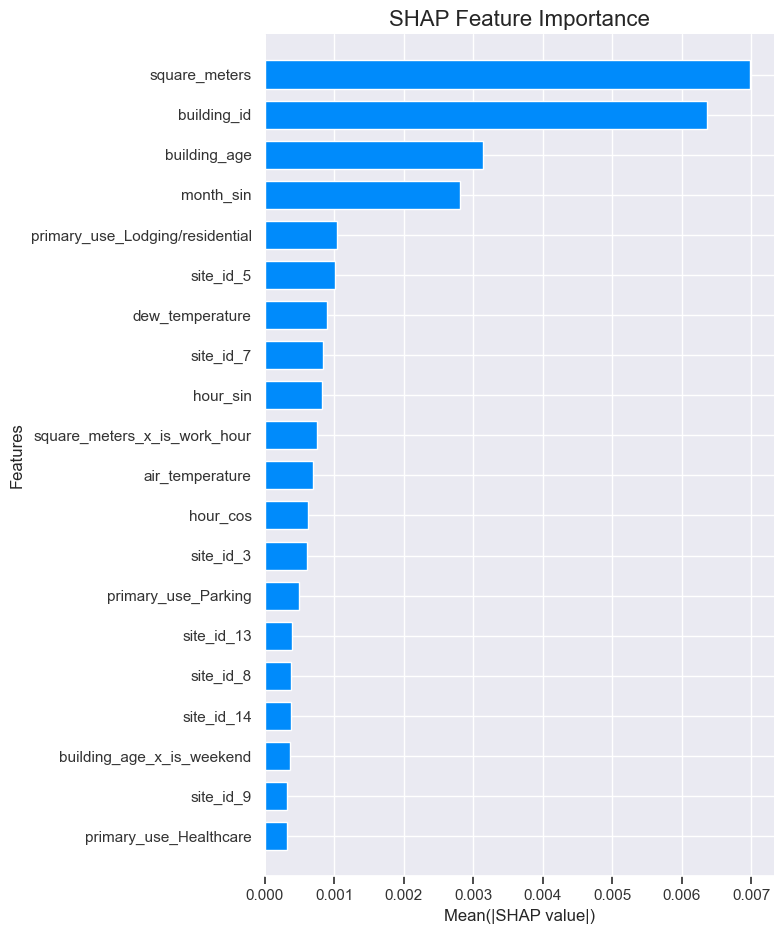

```python
# Create SHAP bar plot
shap.summary_plot(shap_values, X_elec_test, plot_type="bar", show=False)

# Customize title and label fonts
plt.title("SHAP Feature Importance", fontsize=16)
plt.xlabel("Mean(|SHAP value|)", fontsize=12)
plt.ylabel("Features", fontsize=12)

# Customize tick label size
plt.xticks(fontsize=11)
plt.yticks(fontsize=11)

# Show the customized plot
plt.tight_layout()
plt.show()
```

#### **SHAP feature importance interpretation**

The table below shows the top features based on their **mean absolute SHAP value**, which represents each feature's average contribution to the model’s electricity consumption predictions.

[output not shown]

**Key Takeaways**

- **Building-specific features** (`square_meters`, `building_id`, `building_age`) dominate the explanation of predictions, which aligns with domain intuition.
- **Cyclical time features** (`month_sin`, `hour_sin`, `hour_cos`) reflect **seasonality and usage rhythms**.
- **Location and usage-based encodings** (`site_id_*`, `primary_use_*`) help the model learn **regional or functional variation**.
- **Interaction terms** (e.g., `square_meters × is_work_hour`) uncover **nonlinear patterns** that are crucial in real-world energy modeling.

**3. SHAP Beeswarm (Feature Impact Distribution)**

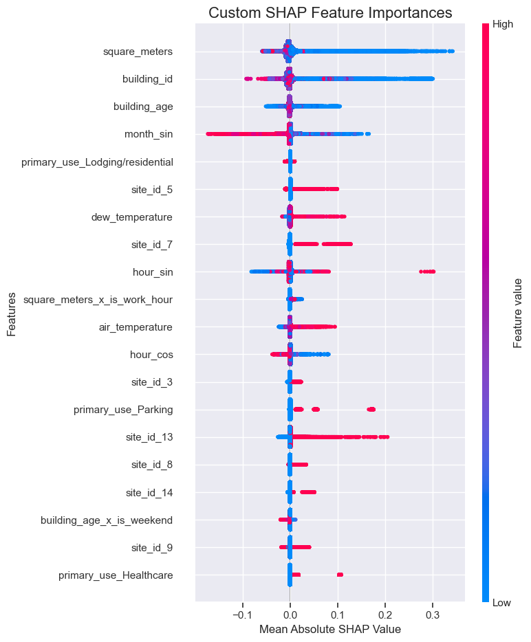

```python
# Create SHAP summary plot
shap.summary_plot(shap_values, X_elec_test, show=False)

# Customize title and labels
plt.title("Custom SHAP Feature Importances", fontsize=16)
plt.xlabel("Mean Absolute SHAP Value", fontsize=12)
plt.ylabel("Features", fontsize=12)

# Customize tick label size
plt.xticks(fontsize=11)
plt.yticks(fontsize=11)

# Adjust layout and show the customized plot
plt.tight_layout()
plt.show()
```

**4. SHAP Dependence (Nonlinear Interaction)**

- **Air-temperature**

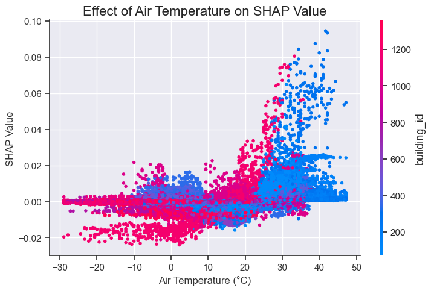

```python
# Plot SHAP dependence with show=False
shap.dependence_plot("air_temperature", shap_values, X_elec_test, show=False)

# Customize title and labels
plt.title("Effect of Air Temperature on SHAP Value", fontsize=16)
plt.xlabel("Air Temperature (°C)", fontsize=12)
plt.ylabel("SHAP Value", fontsize=12)

# Customize tick label size
plt.xticks(fontsize=11)
plt.yticks(fontsize=11)

# Adjust layout and show the customized plot
plt.tight_layout()
plt.show()
```

#### **Effect of air temperature on model predictions (via SHAP Values)**

The SHAP dependence plot for `air_temperature` reveals how air temperature influences electricity usage predictions across the full range of observed values:

1. **Extreme Cold (-30°C to -10°C):**
   - SHAP values are **mostly concentrated around 0**, with some points between **-0.02 and -0.01**.
   - ➤ This suggests the model predicts **little impact of very low temperatures**, though a few buildings show a **slight drop** in expected consumption—possibly due to reduced HVAC activity or high insulation efficiency.
2. **Moderate Temperatures (-10°C to 10°C):**
   - SHAP values are more dispersed, ranging between **-0.02 and 0.02**.
   - ➤ This reflects **greater sensitivity** of the model, likely capturing **seasonal heating effects** or **fluctuations in building usage** in this transitional zone.
3. **Warm Conditions (10°C to 25°C):**
   - SHAP values range between **-0.01 and 0.02**, showing relatively balanced influence.
   - ➤ The model appears to associate **moderate temperatures with stable or slightly increasing energy demand**, possibly due to **ventilation or partial cooling loads**.
4. **Hot Weather (25°C to 48°C):**
   - Most SHAP values fall between **0 and 0.03**, with **a higher density of outliers** reaching up to **0.08**.
   - ➤ This indicates that **high temperatures often lead to increased predicted electricity usage**, likely driven by **air conditioning demand**, with some buildings responding much more strongly than others.
- **Building aire `square_meters`**

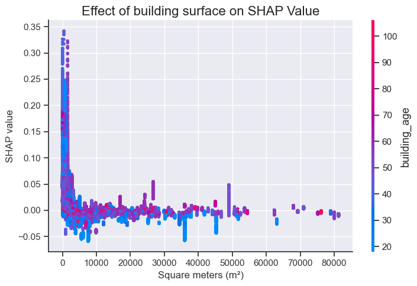

```python
# Plot SHAP dependence on building surfaces
shap.dependence_plot("square_meters", shap_values, X_elec_test, show=False)

# Customize title and labels
plt.title("Effect of building surface on SHAP Value", fontsize=16)
plt.xlabel("Square meters (m²)", fontsize=12)
plt.ylabel("SHAP value", fontsize=12)

# Customize tick label size
plt.xticks(fontsize=11)
plt.yticks(fontsize=11)

# Adjust layout and show the customized plot
plt.tight_layout()
plt.show()
```

#### **Effect of building area on model predictions (via SHAP Values)**

The SHAP dependence plot for `square_meters` reveals how building size affects electricity consumption predictions:

1. **Smaller Buildings (square_meters < ~2000 m²):**
   - SHAP values range from **-0.05 to 0.35**.
   - ➤ This wide spread suggests that the model sees **greater variation in energy behavior among smaller buildings**. These differences could be due to **diverse usage types, insulation quality, or operational schedules** within the small-building group.
2. **Larger Buildings (square_meters > ~2000 m²):**
   - SHAP values are **clustered around 0**, typically between **-0.02 and 0.02**.
   - ➤ The model predicts **more consistent energy use behavior** among large buildings, possibly because **larger facilities have standardized systems (e.g., HVAC, lighting) and predictable occupancy patterns**.

➡️ **Interpretation:**  
The SHAP results suggest that **smaller buildings contribute more unpredictability** to electricity demand patterns, while **larger buildings exhibit more stable and uniform behavior** in the model’s perspective.

#### **c. Error distribution (Residuals)**

- **Histogram of Residuals**

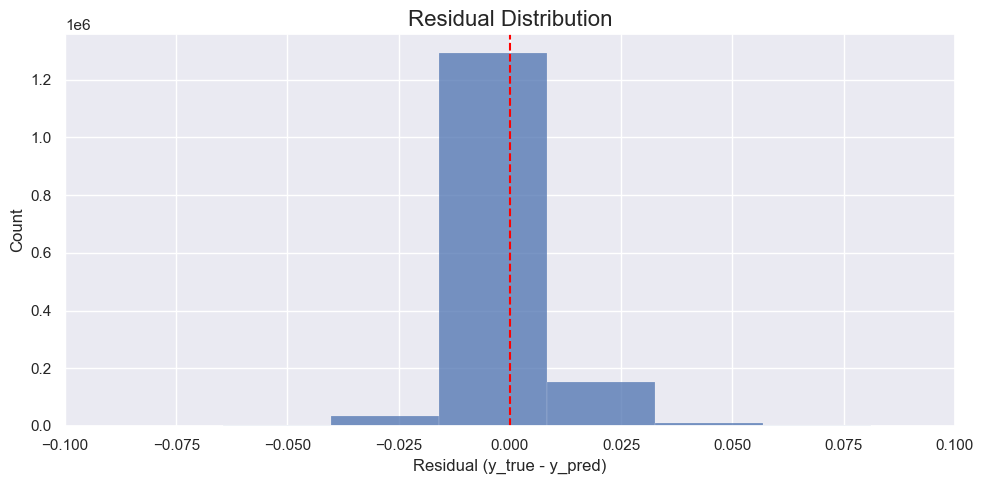

```python
residuals = y_elec_test - pred_orig

plt.figure(figsize=(10, 5))
sns.histplot(residuals, bins=500, kde=False)
plt.axvline(0, color='red', linestyle='--')
plt.title("Residual Distribution", fontsize=16)
plt.xlabel("Residual (y_true - y_pred)", fontsize=12)

plt.xlim(-0.1, 0.1)
plt.xticks(fontsize=11)
plt.yticks(fontsize=11)
plt.tight_layout()
plt.show()
```

#### **Error Distribution (Residuals Analysis)**

The residuals (difference between true and predicted electricity values) help evaluate model accuracy and uncover systematic biases.

➡️ **Interpretation:**  
The model shows **strong predictive performance overall**, with **errors centered tightly around zero**, and **only a small portion of moderate or extreme errors**. This suggests both **low bias and low variance** on the validation set.

#### **d. Error analysis by building, time, and weather**

- **Error by building_id**

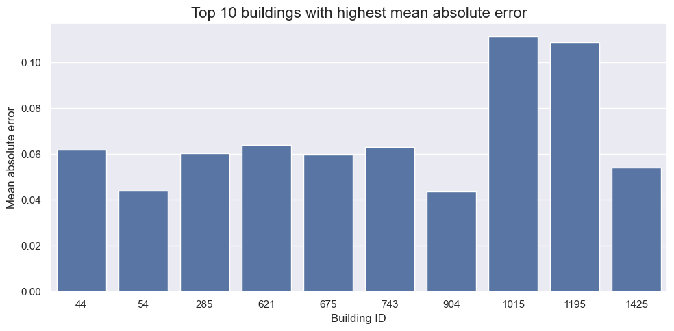

```python
val_df = X_elec_test.copy()

val_df['true'] = y_elec_test.values
val_df['pred'] = pred_orig
val_df['residual'] = val_df['true'] - val_df['pred']

building_errors = val_df.groupby('building_id')['residual'].apply(lambda x: np.mean(np.abs(x)))
top_error_buildings = building_errors.sort_values(ascending=False).head(10)

plt.figure(figsize=(10, 5))
sns.barplot(x=top_error_buildings.index, y=top_error_buildings.values)

plt.title("Top 10 buildings with highest mean absolute error", fontsize=16)
plt.ylabel("Mean absolute error", fontsize=12)
plt.xlabel("Building ID", fontsize=12)
plt.xticks(fontsize=11)
plt.yticks(fontsize=11)
plt.tight_layout()
plt.show()
```

```python
 building_errors.sort_values(ascending=False).head(10)
```

```
building_id
1015    0.111448
1195    0.108794
621     0.064025
743     0.063206
44      0.062003
285     0.060501
675     0.059813
1425    0.054046
54      0.044100
904     0.043610
Name: residual, dtype: float64
```

#### **Error by Building: Top 10 Buildings with Highest Mean Absolute Error**

Analyzing prediction errors by individual buildings helps identify specific locations where the model struggles most.

The top 10 buildings with the **highest mean absolute error (MAE)** are:

| Building ID | Mean Absolute Error |
| --- | --- |
| 1015 | 0.1114 |
| 1195 | 0.1088 |
| 621 | 0.0640 |
| 743 | 0.0632 |
| 44 | 0.0620 |
| 285 | 0.0605 |
| 675 | 0.0598 |
| 1425 | 0.0540 |
| 54 | 0.0441 |
| 904 | 0.0436 |

**Interpretation:**

- Buildings **1015 and 1195** have **significantly higher errors** than the others (MAE > 0.1), suggesting that these buildings may have:
  - Unique usage patterns not captured by the model.
  - Data quality issues (e.g., outliers or missing features).
  - High variability in electricity usage.
- Other buildings (e.g., 621, 743, 44) also exhibit moderate error, which might warrant further investigation.

➡️ **Next Step:** Examine the **usage type, site, weather patterns, or missing data** in these buildings to understand why errors are higher, and consider:

- Adding building-specific features.
- Revisiting data quality or preprocessing steps.
- **Error by hour of day**

```python
# Recover hour from hour_sin and hour_cos
recovered_hour = np.arctan2(df['hour_sin'], df['hour_cos'])  # angle in radians
recovered_hour = np.degrees(recovered_hour)  # convert to degrees
recovered_hour = (recovered_hour + 360) % 360  # ensure positive angles
recovered_hour = (recovered_hour * 24) / 360   # scale to 0–24
recovered_hour = recovered_hour.round().astype(int) % 24  # round and wrap to 0–23
val_df['hour'] = recovered_hour
```

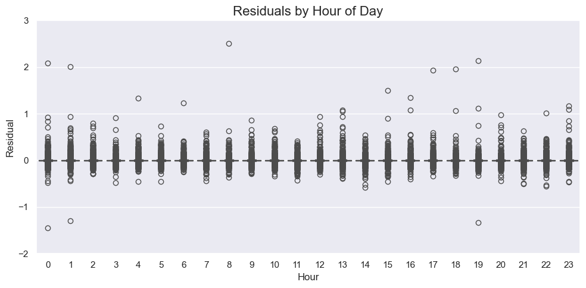

```python
# Plot
plt.figure(figsize=(10, 5))
sns.boxplot(x=val_df['hour'], y=val_df['residual'])

plt.title("Residuals by Hour of Day", fontsize=16)
plt.xlabel("Hour", fontsize=12)
plt.ylabel("Residual", fontsize=12)

plt.ylim(-2., 3.)
plt.xticks(fontsize=11)
plt.yticks(fontsize=11)
plt.tight_layout()
plt.show()
```

#### **Error by Hour of Day**

Analyzing residuals by hour of day helps uncover whether the model’s performance varies across time.

**Observations:**

- 1. For **all hours (0–23)**, the residuals are **centered around 0**, typically within the range of **-0.5 to 0.5**, indicating relatively consistent prediction accuracy throughout the day.
- 2. However, there is a **notable number of outliers**, particularly in the range of **0.5 to 2**, suggesting that:
  - In some hours, the model may **underpredict or overpredict significantly** for certain data points.
  - These outliers may be linked to sudden spikes in energy usage (e.g., due to operational or behavioral shifts).

**Interpretation:**

- While the central tendency of residuals is stable, the presence of outliers points to **potential modeling gaps during peak or off-peak hours**.
- Further analysis could involve examining **hourly patterns by building type or season** to refine predictions during those times.

➡️ **Next Step:** Investigate whether these outliers occur in specific:

- **Buildings** (e.g., offices vs. residential),
- **Weather conditions** (e.g., hot afternoons),
- Or **event-driven behaviors** (e.g., HVAC start-up periods).
- **Error by air temperature**

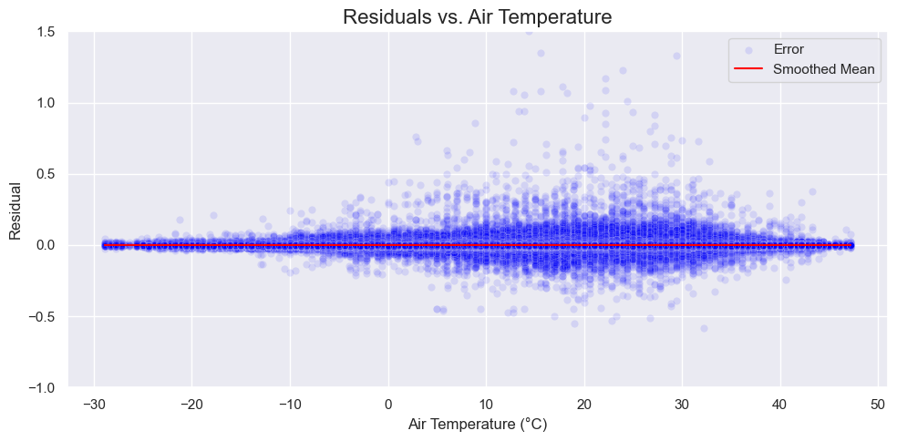

```python
plt.figure(figsize=(10, 5))

sns.scatterplot(x=val_df['air_temperature'], y=val_df['residual'], alpha=0.1, color='blue', label='Error')
sns.lineplot(x=val_df['air_temperature'], y=val_df['residual'].rolling(5000).mean(), color='red', label='Smoothed Mean')

plt.title("Residuals vs. Air Temperature", fontsize=16)
plt.xlabel("Air Temperature (°C)", fontsize=12)
plt.ylabel("Residual", fontsize=12)

plt.ylim(-1., 1.5)
plt.xticks(fontsize=11)
plt.yticks(fontsize=11)
plt.tight_layout()
plt.show()
```

#### **Error by air temperature**

Investigating residuals across temperature ranges provides insight into how well the model adapts to different thermal conditions, which can significantly affect energy consumption patterns.

**Observations**

1. **From -30°C to -10°C**:  
   Residuals are **very close to 0**, mostly contained within a narrow range of approximately **-0.05 to +0.05**, indicating **high model stability in extreme cold**.
2. **From -10°C to +10°C**:  
   The distribution **widens**, with most residuals between **-0.15 and +0.15**, but several **outliers extend from -0.5 to +0.5**, suggesting the model faces more variability during **moderate cold to mild conditions**.
3. **From +10°C to +30°C**:  
   Residuals are broadly distributed within **±0.5**, with some **outliers reaching up to +1.5**, pointing to **less accurate predictions** possibly due to diverse building behaviors or cooling system activity in this range.
4. **Above +30°C**:  
   The residuals **converge more tightly around 0**, and their **amplitude diminishes**, with only **a few notable outliers**, implying improved model performance during **very hot conditions**.

**Interpretation:**

- The model performs **most reliably** in **extremely cold and very hot temperatures**, where building behavior is likely **more predictable** (e.g., consistent heating or cooling loads).
- The **largest residual variation** occurs in the **mild to moderate temperature range (-10°C to +30°C)**, likely due to **nonlinear shifts in HVAC usage**, **occupant behavior**, or **transitional modes** (e.g., heating-to-cooling switchovers).

➡️ **Next Step**: Consider incorporating **temperature interaction terms**, or **training separate models by season**, to better capture behavior in transitional temperature zones.

### **Save the model with joblib**

```python
import joblib

joblib.dump(model_orig, "C:/Disc D/Projects to publish/Projects to do/Energy Efficiency Analytics in Buildings/electricity_lgbm_model.pkl")
```

```
['C:/Disc D/Projects to publish/Projects to do/Energy Efficiency Analytics in Buildings/electricity_lgbm_model.pkl']
```

### **Calculate energy density predictions on labeled data**

```python
# List of columns to store
List_cols_store = ['building_id', 'site_id', 'primary_use', 'year_built', 'air_temperature', 'square_meters',
                   'hour', 'dayofweek', 'month', 'is_weekend', 'is_work_hour', 'season', 'building_age', 'era_bin',
                   'is_modern_building', 'Energy_kWh', 'energy_density_kwh_m2']

# Build a dataframe
elec_train_preds = sampled_df[List_cols_store]
# Predict and save energy_density
y_preds = model_orig.predict(X_elec)
elec_train_preds['energy_density_pred'] = y_preds
```

```python
elec_train_preds.head(2)
```

|  | building_id | site_id | primary_use | year_built | air_temperature | square_meters | hour | dayofweek | month | is_weekend | is_work_hour | season | building_age | era_bin | is_modern_building | Energy_kWh | energy_density_kwh_m2 | energy_density_pred |
| --- | --- | --- | --- | --- | --- | --- | --- | --- | --- | --- | --- | --- | --- | --- | --- | --- | --- | --- |
| 0 | 0 | 0 | Education | 2008.0 | 2.2 | 690.455096 | 11 | 6 | 1 | 1 | 0 | Winter | 17.0 | 2000–2010 | 0 | 0.0 | 0.0 | 0.004893 |
| 1 | 0 | 0 | Education | 2008.0 | 1.7 | 690.455096 | 13 | 6 | 1 | 1 | 0 | Winter | 17.0 | 2000–2010 | 0 | 0.0 | 0.0 | 0.005100 |

```python
# save electricity database as csv file
elec_train_preds.to_csv("C:/Disc D/Projects to publish/Projects to do/Energy Efficiency Analytics in Buildings/elec_sample_train_data.csv", index=False)
```

## **2. Chilled Water**

```python
# Load child water database
chilled_water_train = pd.read_csv("C:/Disc D/Projects to publish/Projects to do/Energy Efficiency Analytics in Buildings/chilled_water_train.csv")
```

```python
chilled_water_train.shape
```

```
(4182440, 31)
```

### **Feature Engineering & data preparation**

**Enhance the dataset by adding useful dummied features and interaction features**

#### **a. Creating dummy variables for `site_id`, `primary_use` and `season` features**

```python
# Copying 'df_train_combined' dataframe into 'df_train_combined_dummy' dataframe
chilled_water_train_dummy = chilled_water_train.copy()

# Generate dummy variables and concatenate
for col in ["site_id", "primary_use", "season"]:
    dummies = pd.get_dummies(chilled_water_train_dummy[col], prefix=col, drop_first=True)
    chilled_water_train_dummy = pd.concat([chilled_water_train_dummy, dummies], axis=1)
```

```python
chilled_water_train_dummy.head(2)
```

|  | building_id | Energy_type | timestamp | site_id | primary_use | year_built | air_temperature | cloud_coverage | dew_temperature | precip_depth_1_hr | sea_level_pressure | wind_direction | wind_speed | square_meters | Energy_kWh | hour | dayofweek | month | is_weekend | is_work_hour | season | hour_sin | hour_cos | dayofweek_sin | dayofweek_cos | month_sin | month_cos | building_age | era_bin | … |
| --- | --- | --- | --- | --- | --- | --- | --- | --- | --- | --- | --- | --- | --- | --- | --- | --- | --- | --- | --- | --- | --- | --- | --- | --- | --- | --- | --- | --- | --- | --- |
| 0 | 7 | 1 | 2016-02-29 09:00:00 | 0 | Education | 1989.0 | 12.8 | 2.0 | 8.9 | 0.0 | 1021.9 | 0.0 | 0.0 | 11248.137822 | 6531.709474 | 9 | 0 | 2 | 0 | 1 | Winter | 0.707107 | -0.707107 | 0.0 | 1.0 | 0.866025 | 0.5 | 36.0 | 80–2000 | … |
| 1 | 9 | 1 | 2016-02-29 09:00:00 | 0 | Office | 2010.0 | 12.8 | 2.0 | 8.9 | 0.0 | 1021.9 | 0.0 | 0.0 | 2508.381000 | 2078.266401 | 9 | 0 | 2 | 0 | 1 | Winter | 0.707107 | -0.707107 | 0.0 | 1.0 | 0.866025 | 0.5 | 15.0 | 2000–2010 | … |

```python
chilled_water_train_dummy.shape
```

```
(4182440, 56)
```

**After feature engineering and dummying some features, the train dataset is composed of 4182440 rows and 56 columns.**

- **Convert boolean values (True/False) to binary integers (1/0).**

```python
# Boolean features
bool_cols = ['site_id_2', 'site_id_6', 'site_id_7', 'site_id_9','site_id_10','site_id_11','site_id_13',
             'site_id_14','site_id_15', 'primary_use_Entertainment/public assembly','primary_use_Food sales and service',
             'primary_use_Healthcare', 'primary_use_Lodging/residential','primary_use_Manufacturing/industrial','primary_use_Office',
             'primary_use_Other', 'primary_use_Parking','primary_use_Public services','primary_use_Religious worship','primary_use_Retail',
             'primary_use_Technology/science', 'primary_use_Utility', 'season_Spring','season_Summer','season_Winter']

chilled_water_train_dummy[bool_cols] = chilled_water_train_dummy[bool_cols].astype(int)
```

```python
chilled_water_train_dummy.head(2)
```

|  | building_id | Energy_type | timestamp | site_id | primary_use | year_built | air_temperature | cloud_coverage | dew_temperature | precip_depth_1_hr | sea_level_pressure | wind_direction | wind_speed | square_meters | Energy_kWh | hour | dayofweek | month | is_weekend | is_work_hour | season | hour_sin | hour_cos | dayofweek_sin | dayofweek_cos | month_sin | month_cos | building_age | era_bin | … |
| --- | --- | --- | --- | --- | --- | --- | --- | --- | --- | --- | --- | --- | --- | --- | --- | --- | --- | --- | --- | --- | --- | --- | --- | --- | --- | --- | --- | --- | --- | --- |
| 0 | 7 | 1 | 2016-02-29 09:00:00 | 0 | Education | 1989.0 | 12.8 | 2.0 | 8.9 | 0.0 | 1021.9 | 0.0 | 0.0 | 11248.137822 | 6531.709474 | 9 | 0 | 2 | 0 | 1 | Winter | 0.707107 | -0.707107 | 0.0 | 1.0 | 0.866025 | 0.5 | 36.0 | 80–2000 | … |
| 1 | 9 | 1 | 2016-02-29 09:00:00 | 0 | Office | 2010.0 | 12.8 | 2.0 | 8.9 | 0.0 | 1021.9 | 0.0 | 0.0 | 2508.381000 | 2078.266401 | 9 | 0 | 2 | 0 | 1 | Winter | 0.707107 | -0.707107 | 0.0 | 1.0 | 0.866025 | 0.5 | 15.0 | 2000–2010 | … |

#### **b. Add the interaction features**

```python
# Add interaction features
chilled_water_train_dummy = add_interaction_features(chilled_water_train_dummy)
```

```python
chilled_water_train_dummy.shape
```

```
(4182440, 177)
```

The sample data is composed of 4,182,440 rows and 177 features. Some unuseful features have to be dropped.

```python
chilled_water_train_dummy.head(1)
```

|  | building_id | Energy_type | timestamp | site_id | primary_use | year_built | air_temperature | cloud_coverage | dew_temperature | precip_depth_1_hr | sea_level_pressure | wind_direction | wind_speed | square_meters | Energy_kWh | hour | dayofweek | month | is_weekend | is_work_hour | season | hour_sin | hour_cos | dayofweek_sin | dayofweek_cos | month_sin | month_cos | building_age | era_bin | … |
| --- | --- | --- | --- | --- | --- | --- | --- | --- | --- | --- | --- | --- | --- | --- | --- | --- | --- | --- | --- | --- | --- | --- | --- | --- | --- | --- | --- | --- | --- | --- |
| 0 | 7 | 1 | 2016-02-29 09:00:00 | 0 | Education | 1989.0 | 12.8 | 2.0 | 8.9 | 0.0 | 1021.9 | 0.0 | 0.0 | 11248.137822 | 6531.709474 | 9 | 0 | 2 | 0 | 1 | Winter | 0.707107 | -0.707107 | 0.0 | 1.0 | 0.866025 | 0.5 | 36.0 | 80–2000 | … |

#### **c. Split the dataset into train and test subsets**

```python
# List of features to drop
fet_to_drop3 = ['Energy_type', 'timestamp', 'site_id', 'primary_use', 'year_built', 'Energy_kWh', 'hour', 'dayofweek',
                'month', 'era_bin', 'season', 'energy_density_kwh_m2', 'air_temp_bin', 'strata_key']

# train dataset
X_chilled_water = chilled_water_train_dummy.drop(columns = [col for col in fet_to_drop3 if col in chilled_water_train_dummy.columns])
y_chilled_water = chilled_water_train_dummy['energy_density_kwh_m2']
```

```python
# We split two dataframes with inputs and targets, each into a train and test dataframe, and store them in variables.
X_chil_train, X_chil_test, y_chil_train, y_chil_test = train_test_split(X_chilled_water, y_chilled_water, test_size=0.3, random_state=42, shuffle=True)
```

```python
# Shape of train and test data subsets
print('Train subset shape: ', X_chil_train.shape)
print('Test subset shape: ', X_chil_test.shape)
```

```
Train subset shape:  (2927708, 165)
Test subset shape:  (1254732, 165)
```

- The train dataset is composed of **2,927,708 rows** and **165 independant features**.
- The test dataset is composed of **1,254,732 rows** and **165 independant features**.

#### **d. Checking for Outliers**

- **Distribution Plot**

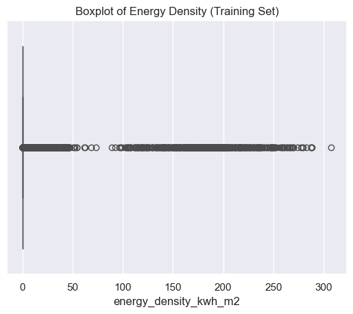

```python
# Example for Energy_kWh
sns.boxplot(x = y_chil_train)
plt.title("Boxplot of Energy Density (Training Set)")
plt.show()
```

As can be observed on the figure, there are a lot of outliers.

- **IQR method**

```python
Q1 = y_chil_train.quantile(0.25)
Q3 = y_chil_train.quantile(0.75)
IQR = Q3 - Q1

outlier_mask = (y_chil_train < (Q1 - 1.5 * IQR)) | (y_chil_train > (Q3 + 1.5 * IQR))
print(f"Outliers: {outlier_mask.sum()} / {len(y_chil_train)}")
```

```
Outliers: 314121 / 2927708
```

For energy density, we have about **314,121 outliers out of 2,927,708 rows** — that's only **~10.7%** of our data.

### **LGBMRegressor Model**

#### **a. IQR Outlier Handling**

Train the model, with "Energy Density" as target variable, on:

- **Original data**
- **Cleaned data (IQR-filtered)**
- **Clipped data (IQR-capped)**

```python
# ----- 1. Clip feature values (optional, for stability) -----
def iqr_clip_columns_inplace(df, cols=None, iqr_multiplier=1.5):
    if cols is None:
        cols = df.select_dtypes(include=np.number).columns

    for col in cols:
        q1 = df[col].quantile(0.25)
        q3 = df[col].quantile(0.75)
        iqr = q3 - q1
        lower = q1 - iqr_multiplier * iqr
        upper = q3 + iqr_multiplier * iqr
        df[col] = df[col].clip(lower=lower, upper=upper)

    return df

# Apply feature clipping
X_capped_chil = iqr_clip_columns_inplace(X_chil_train.copy())

# ----- 2. Compute target variable outliers -----
Q1 = y_chil_train.quantile(0.25)
Q3 = y_chil_train.quantile(0.75)
IQR = Q3 - Q1
lower_bound = Q1 - 1.5 * IQR
upper_bound = Q3 + 1.5 * IQR

outlier_mask = (y_chil_train < lower_bound) | (y_chil_train > upper_bound)
print(f"Outliers in target: {outlier_mask.sum()} / {len(y_chil_train)}")

# ----- Option A: Clip the target variable -----
y_capped_chil = y_chil_train.clip(lower=lower_bound, upper=upper_bound)

# ----- Option B: Filter out outlier rows completely -----
X_filtered_chil = X_capped_chil[~outlier_mask]
y_filtered_chil = y_chil_train[~outlier_mask]
```

```
Outliers in target: 314121 / 2927708
```

```python
X_chil_train.shape
```

```
(2927708, 165)
```

```python
X_filtered_chil.shape
```

```
(2613587, 165)
```

**The dataset without outliers is composed by 2,613,587 rows.**

#### **b. Train models and compare**

```python
# Original data
model_orig_chil = train_lgbm(X_chil_train, y_chil_train)
pred_orig_chil = model_orig_chil.predict(X_chil_test)
evaluate_model("Original", y_chil_test, pred_orig_chil)

# IQR-filtered data
model_filtered_chil = train_lgbm(X_filtered_chil, y_filtered_chil)
pred_filtered_chil = model_filtered_chil.predict(X_chil_test)
evaluate_model("Filtered (IQR removed)", y_chil_test, pred_filtered_chil)

# IQR-capped data
model_capped_chil = train_lgbm(X_capped_chil, y_capped_chil)
pred_capped_chil = model_capped_chil.predict(X_chil_test)
evaluate_model("Capped (IQR clipped)", y_chil_test, pred_capped_chil)
```

```
[LightGBM] [Warning] Found whitespace in feature_names, replace with underlines
[LightGBM] [Info] Auto-choosing col-wise multi-threading, the overhead of testing was 1.431764 seconds.
You can set `force_col_wise=true` to remove the overhead.
[LightGBM] [Info] Total Bins 8923
[LightGBM] [Info] Number of data points in the train set: 2927708, number of used features: 165
[LightGBM] [Info] Start training from score 0.242099
--- Original ---
RMSE: 1.0744681749749176
MAE: 0.08536359330001818
Median AE: 0.030922526428668752
R²: 0.8580722459823351
SMAPE: 83.21 %

[LightGBM] [Warning] Found whitespace in feature_names, replace with underlines
[LightGBM] [Info] Auto-choosing col-wise multi-threading, the overhead of testing was 0.435777 seconds.
You can set `force_col_wise=true` to remove the overhead.
[LightGBM] [Info] Total Bins 6321
[LightGBM] [Info] Number of data points in the train set: 2613587, number of used features: 42
[LightGBM] [Info] Start training from score 0.079402
--- Filtered (IQR removed) ---
RMSE: 2.851454810071502
MAE: 0.1711988624529599
Median AE: 0.018513043816423637
R²: 0.00043002188156060495
SMAPE: 80.64 %

[LightGBM] [Warning] Found whitespace in feature_names, replace with underlines
[LightGBM] [Info] Auto-choosing col-wise multi-threading, the overhead of testing was 0.491018 seconds.
You can set `force_col_wise=true` to remove the overhead.
[LightGBM] [Info] Total Bins 6325
[LightGBM] [Info] Number of data points in the train set: 2927708, number of used features: 42
[LightGBM] [Info] Start training from score 0.115421
--- Capped (IQR clipped) ---
RMSE: 2.8426077348500423
MAE: 0.157645110314001
Median AE: 0.020190885485542806
R²: 0.006623037428153067
SMAPE: 78.21 %
```

#### **Interpretations:**

The results clearly show how outlier handling affected the model's performance:

**LightGBM Regression Results Comparison**

| **Metric** | **Original (All data)** | **Filtered (IQR removed)** | **Capped (IQR clipped)** |
| --- | --- | --- | --- |
| **# Samples** | 2,927,708 | 2,613,587 | 2,927,708 |
| **# Features** | 165 | 42 | 42 |
| **RMSE** | 1.0745 | 2.8515 | 2.8426 |
| **MAE** | 0.0854 | 0.1712 | 0.1576 |
| **Median AE** | 0.0309 | 0.0185 | 0.0202 |
| **R² Score** | 0.8581 | 0.0004 | 0.0066 |
| **SMAPE (%)** | 83.21 | 80.64 | 78.21 |

**Notes:**

- The model performs very well on the original data, indicating it captures meaningful patterns.
- Removing outliers entirely using IQR filtering broke the model’s ability to generalize. It may have discarded too much useful data or led to underfitting.
- Capping outliers is less harmful than removing them, but the model still struggles with capturing variance. The predictive power is nearly lost.

**Overall Insights:**

- **Best performance** is observed on the **original dataset** (no outlier treatment).
- **Outlier filtering/capping may not be suitable** in this case, as it severely reduces model accuracy and R².
- **Recommendation:** Use the original data for modeling, and handle outliers at prediction time (e.g., apply post-processing, thresholds) or model them separately if needed.

### **Feature importances**

- **Get N top important features**

```python
# Get absolute and relative importances
importances = model_orig_chil.feature_importances_
features = X_chilled_water.columns
relative_importances = importances / importances.sum()

# Select the top N features
top_N = 100  # Change this to the desired number of features
top_features, top_importances = select_top_features(relative_importances, features, N=top_N)

print(f"Top {top_N} Features:")
print(' ')
for i, (feature, importance) in enumerate(zip(top_features, top_importances), 1):
    print(f"{i}. {feature}: {importance:.7f}")

Sum_top = top_importances.sum()
print(' ')
print(f" Sum of the Top {top_N} Features Importances: {Sum_top:.3f}")
```

```
Top 100 Features:

1. building_id: 0.1121000
2. square_meters: 0.0797000
3. sea_level_pressure: 0.0470333
4. dew_temperature: 0.0456667
5. sea_level_pressure_x_month_cos: 0.0429000
6. air_temperature: 0.0415000
7. month_sin: 0.0391000
8. dew_temperature_x_month_cos: 0.0375333
9. building_age: 0.0372667
10. hour_sin: 0.0322333
11. air_temperature_x_month_cos: 0.0316000
12. air_temperature_x_square_meters: 0.0260000
13. dew_temperature_x_square_meters: 0.0252333
14. air_temperature_x_hour_cos: 0.0186000
15. wind_direction: 0.0173000
16. dew_temperature_x_hour_cos: 0.0166667
17. wind_direction_x_month_cos: 0.0161333
18. site_id_6: 0.0156333
19. primary_use_Other_x_hour_cos: 0.0143000
20. sea_level_pressure_x_hour_cos: 0.0133333
21. dayofweek_sin: 0.0119333
22. primary_use_Entertainment/public assembly_x_dayofweek_cos: 0.0118000
23. wind_direction_x_hour_cos: 0.0117667
24. dayofweek_cos: 0.0108000
25. wind_speed_x_month_cos: 0.0100333
26. wind_speed_x_hour_cos: 0.0096000
27. dew_temperature_x_is_weekend: 0.0095333
28. primary_use_Entertainment/public assembly_x_hour_cos: 0.0088333
29. wind_speed: 0.0085333
30. primary_use_Other_x_dayofweek_cos: 0.0083667
31. square_meters_x_hour_cos: 0.0083000
32. site_id_14: 0.0082000
33. sea_level_pressure_x_is_weekend: 0.0076333
34. air_temperature_x_is_work_hour: 0.0073333
35. sea_level_pressure_x_is_work_hour: 0.0071000
36. month_cos: 0.0066000
37. dew_temperature_x_is_work_hour: 0.0064333
38. air_temperature_x_is_weekend: 0.0057000
```

[output cut: 49 more lines]

```
88. is_modern_building_x_is_weekend: 0.0009000
89. primary_use_Utility_x_season_Summer: 0.0008667
90. primary_use_Lodging/residential_x_season_Summer: 0.0008667
91. primary_use_Public services_x_season_Spring: 0.0008000
92. primary_use_Entertainment/public assembly_x_is_work_hour: 0.0008000
93. primary_use_Office_x_season_Summer: 0.0007667
94. primary_use_Office_x_dayofweek_cos: 0.0007333
95. building_age_x_is_weekend: 0.0007000
96. primary_use_Manufacturing/industrial_x_dayofweek_cos: 0.0007000
97. primary_use_Lodging/residential_x_season_Spring: 0.0005667
98. primary_use_Manufacturing/industrial_x_season_Summer: 0.0005333
99. primary_use_Food sales and service_x_dayofweek_cos: 0.0005333
100. cloud_coverage_x_is_work_hour: 0.0005333

 Sum of the Top 100 Features Importances: 0.990
```

- **Get the top interaction features**

```python
# Convert to pandas Series first
top_features_series = pd.Series(top_features)

# Then filter and sort
top_intera_feats = top_features_series[top_features_series.str.contains('_x_')]
print(top_intera_feats)

print(len(top_intera_feats))
```

```
4                        sea_level_pressure_x_month_cos
7                           dew_temperature_x_month_cos
10                          air_temperature_x_month_cos
11                      air_temperature_x_square_meters
12                      dew_temperature_x_square_meters
13                           air_temperature_x_hour_cos
15                           dew_temperature_x_hour_cos
16                           wind_direction_x_month_cos
18                         primary_use_Other_x_hour_cos
19                        sea_level_pressure_x_hour_cos
21    primary_use_Entertainment/public assembly_x_da...
22                            wind_direction_x_hour_cos
24                               wind_speed_x_month_cos
25                                wind_speed_x_hour_cos
26                         dew_temperature_x_is_weekend
```

[output cut: 53 more lines]

**From these 100 top important features, 66 ones are interaction features.**

#### **Interpretations:**

**1. General Overview** Sum of Top 100 Importances: 0.990

→ This suggests that your model’s prediction relies almost entirely (99%) on these 100 features, indicating effective feature selection and engineering.

Number of Interaction Features: 66

→ These are features resulting from multiplying or combining two variables (e.g., air_temperature_x_month_cos), and they dominate the list—reinforcing the value of feature interactions in improving model accuracy.

**2. Most Important Features (Top 10)**

| Rank | Feature | Importance |
| --- | --- | --- |
| 1 | building_id | 0.1121 |
| 2 | square_meters | 0.0797 |
| 3 | sea_level_pressure | 0.0470 |
| 4 | dew_temperature | 0.0457 |
| 5 | sea_level_pressure_x_month_cos | 0.0429 |
| 6 | air_temperature | 0.0415 |
| 7 | month_sin | 0.0391 |
| 8 | dew_temperature_x_month_cos | 0.0375 |
| 9 | building_age | 0.0373 |
| 10 | hour_sin | 0.0322 |

**Notes:**

- **Static building attributes** like building_id, square_meters, and building_age are key, which is expected as chilled water use is strongly tied to building size and type.
- **Weather variables** (sea_level_pressure, dew_temperature, air_temperature) and their **interactions with time features** like month_cos are also critical. This confirms that external weather patterns and seasonal effects drive chilled water needs.
- **Time features** (hour_sin, month_sin) matter too, suggesting daily and monthly cycles in chilled water usage.

**3. Interaction Features** Interaction features like air_temperature_x_month_cos or dew_temperature_x_hour_cos add **context** and **non-linearity** by modeling how one feature's effect varies with another (e.g., temperature's effect may differ by month or hour).

🔹 **Notable Interaction Types:**

- **Weather × Time:**

e.g., air_temperature_x_month_cos, dew_temperature_x_hour_cos, sea_level_pressure_x_is_weekend

→ Indicates chilled water usage responds to temperature and pressure differently at different times/days.

- **Building/Usage × Time or Season:**

e.g., primary_use_Other_x_hour_cos, primary_use_Office_x_season_Summer

→ Shows how usage types affect load patterns throughout the day/year.

- **Size × Time or Category:**

e.g., square_meters_x_hour_cos, square_meters_x_is_weekend

→ Large buildings have different time-based demand profiles.

- **Work/Weekend/Modernity Flags:**

e.g., dew_temperature_x_is_weekend, air_temperature_x_is_modern_building

→ Weekends and building type influence cooling needs and response to weather.

**Conclusion:** The interaction features explain variability in chilled water consumption across time, building type, and weather.

**4. Key Insights for Modeling**

| Insight | Interpretation |
| --- | --- |
| Weather variables are important | `air_temperature`, `dew_temperature`, `sea_level_pressure` all rank high. Interactions boost their explanatory power. |
| Time-based interactions matter | Features like `hour_sin`, `month_sin`, and combinations like `*_x_hour_cos` capture daily/seasonal trends effectively. |
| Building-specific patterns dominate | `building_id`, `square_meters`, and interaction features involving `primary_use_*` and `building_age` show clear segmentation in demand by building type. |
| Model relies heavily on engineered features | 66% of top features are interactions → Feature engineering significantly improves predictive power. |
| Weekend/work hour influence | Features involving `is_weekend` or `is_work_hour` suggest behavioral patterns in chilled water usage (e.g., reduced usage on weekends). |

### **SHAP Values (Global & Local Interpretability)**

To better understand how each feature influences the model's predictions, we use SHAP (SHapley Additive exPlanations), a game-theoretic approach to explain individual predictions. SHAP values provide both global insights into feature importance and local explanations for specific instances.

#### **1. SHAP Setup**

```python
import shap

# Compute SHAP values
explainer = shap.TreeExplainer(model_orig_chil)
shap_values = explainer.shap_values(X_chil_test)
```

#### **2. SHAP Summary Plot (Global Importance)**

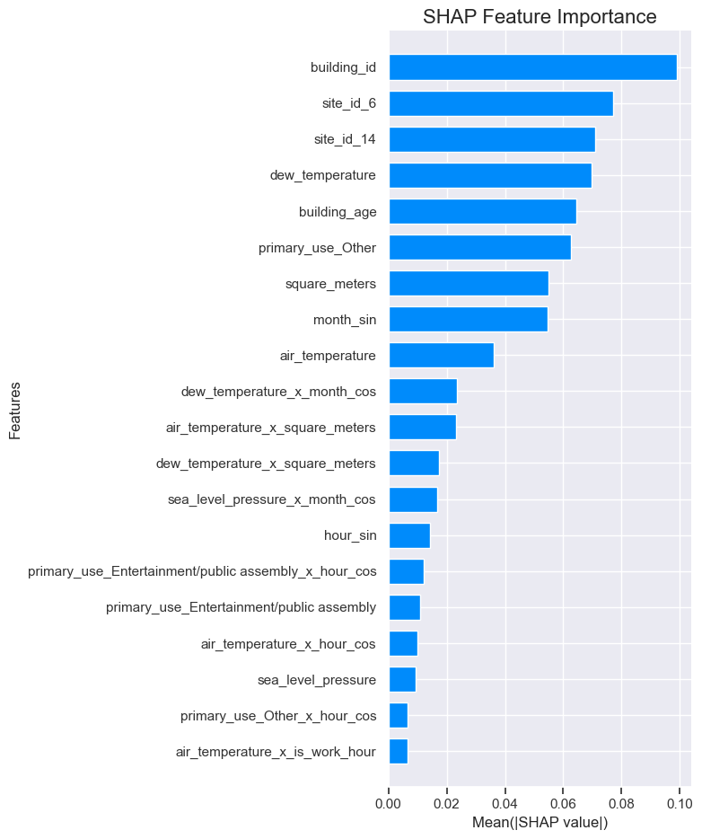

```python
# Create SHAP bar plot
shap.summary_plot(shap_values, X_chil_test, plot_type="bar", show=False)

# Customize title and label fonts
plt.title("SHAP Feature Importance", fontsize=16)
plt.xlabel("Mean(|SHAP value|)", fontsize=12)
plt.ylabel("Features", fontsize=12)

# Customize tick label size
plt.xticks(fontsize=11)
plt.yticks(fontsize=11)

# Show the customized plot
plt.tight_layout()
plt.show()
```

```python
# Convert to DataFrame for easier analysis
shap_df = pd.DataFrame(shap_values, columns= X_chil_test.columns)

# Compute mean absolute SHAP values per feature
mean_abs_shap = shap_df.abs().mean().sort_values(ascending=False)

# Select top 20 features
top_20_features = mean_abs_shap.head(20).index

# Extract SHAP values for these features
top_20_shap_values = shap_df[top_20_features]

# Display result
print("SHAP values of top 20 features:")
top_20_shap_values.abs().mean().sort_values(ascending=False)
```

```
SHAP values of top 20 features:
```

```
building_id                                             0.098957
site_id_6                                               0.077014
site_id_14                                              0.070978
dew_temperature                                         0.069798
building_age                                            0.064492
primary_use_Other                                       0.062682
square_meters                                           0.054802
month_sin                                               0.054528
air_temperature                                         0.036051
dew_temperature_x_month_cos                             0.023523
air_temperature_x_square_meters                         0.023102
dew_temperature_x_square_meters                         0.017477
sea_level_pressure_x_month_cos                          0.016814
hour_sin                                                0.014279
primary_use_Entertainment/public assembly_x_hour_cos    0.012263
primary_use_Entertainment/public assembly               0.011031
air_temperature_x_hour_cos                              0.009967
sea_level_pressure                                      0.009273
primary_use_Other_x_hour_cos                            0.006710
air_temperature_x_is_work_hour                          0.006673
dtype: float64
```

#### **SHAP-Based Interpretation of Model Behavior**

The table below shows the top features based on their **mean absolute SHAP value**, which represents each feature's average contribution to the model’s chilled water consumption predictions.

| Rank | Feature | SHAP Importance | Interpretation |
| --- | --- | --- | --- |
| 1 | `building_id` | 0.099 | Captures building-specific consumption patterns. Very high influence – likely due to structural and operational differences across buildings. |
| 2 | `site_id_6` | 0.077 | Indicates that buildings at site 6 behave distinctly in terms of chilled water usage. |
| 3 | `site_id_14` | 0.071 | Similar to above; this site has significant behavioral deviation from average. |
| 4 | `dew_temperature` | 0.070 | Humidity-related indicator. Affects cooling demand significantly. |
| 5 | `building_age` | 0.064 | Older/newer buildings likely have different HVAC efficiencies or insulation performance. |
| 6 | `primary_use_Other` | 0.063 | Usage category plays a major role – ‘Other’ buildings show a distinct pattern. |
| 7 | `square_meters` | 0.055 | Larger buildings generally consume more chilled water, although interaction terms adjust for this. |
| 8 | `month_sin` | 0.055 | Captures seasonality – when usage peaks (summer months, etc.). |
| 9 | `air_temperature` | 0.036 | Core driver of cooling demand – higher temperatures lead to more chilled water usage. |
| 10 | `dew_temperature_x_month_cos` | 0.024 | Interaction that captures how humidity and seasonality affect cooling jointly. |
| 11 | `air_temperature_x_square_meters` | 0.023 | Larger buildings respond differently to temperature – non-linear impact. |
| 12 | `dew_temperature_x_square_meters` | 0.017 | Same idea: big/humid buildings may need more cooling. |
| 13 | `sea_level_pressure_x_month_cos` | 0.017 | Captures indirect weather-season effects (e.g., storms, high-pressure systems). |
| 14 | `hour_sin` | 0.014 | Captures daily patterns – such as business hours vs. off hours. |
| 15 | `primary_use_Entertainment/public assembly_x_hour_cos` | 0.012 | Time-based behavior specific to entertainment buildings – perhaps peaking in evening hours. |
| 16 | `primary_use_Entertainment/public assembly` | 0.011 | These buildings have unique usage patterns – perhaps more variable or peaky. |
| 17 | `air_temperature_x_hour_cos` | 0.010 | Interaction shows how temperature sensitivity varies across hours of day. |
| 18 | `sea_level_pressure` | 0.009 | May affect HVAC system performance indirectly (e.g., ventilation pressure). |
| 19 | `primary_use_Other_x_hour_cos` | 0.007 | Captures time-based patterns in non-standard building usage. |
| 20 | `air_temperature_x_is_work_hour` | 0.007 | Highlights how temperature impact is stronger/weaker during work hours. |

**Key Insights from This SHAP Analysis**

- **1. Building and Site Identity Dominate:** `building_id`, `site_id_6`, `site_id_14`, `building_age`, and `primary_use_*` have high SHAP importance → the model is learning strong **location-specific and building-specific behaviors**.
- **2. Weather Still Plays a Strong Role:** `dew_temperature`, `air_temperature`, and their interactions (especially with time and building size) are crucial. Shows model **sensitivity to climate effects**.
- **3. Temporal Patterns Are Important:** Features like `month_sin`, `hour_sin`, and interaction terms with `is_work_hour` show that the model captures **cyclical and behavioral trends over time (seasonal and daily)**.
- **4. Interactions Are Key:** Many of the top features are interaction terms (e.g., `air_temperature_x_square_meters`) → confirms that **feature engineering was successful in boosting predictive power**.

#### **3. SHAP Dependence (Nonlinear Interaction)**

- **Air-temperature**

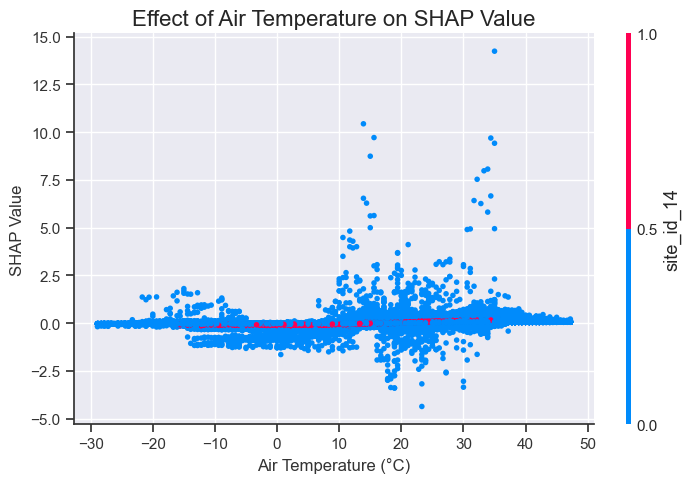

```python
# Plot SHAP dependence with show=False
shap.dependence_plot("air_temperature", shap_values, X_chil_test, show=False)

# Customize title and labels
plt.title("Effect of Air Temperature on SHAP Value", fontsize=16)
plt.xlabel("Air Temperature (°C)", fontsize=12)
plt.ylabel("SHAP Value", fontsize=12)

# Customize tick label size
plt.xticks(fontsize=11)
plt.yticks(fontsize=11)

# Adjust layout and show the customized plot
plt.tight_layout()
plt.show()
```

#### **Effect of air temperature on model predictions (via SHAP values)**

SHAP value analysis provides insights into how **air temperature** affects model predictions for chilled water usage:

**Key Takeaway**:  
Air temperature shows **complex, non-linear effects** on model predictions, especially in the **10°C to 35°C** range, where the model is most reactive. Effects at extreme temperatures tend to **stabilize**, indicating saturation or operational limits in the cooling system.

#### **4. Error distribution (Residuals)**

- **Histogram of Residuals**

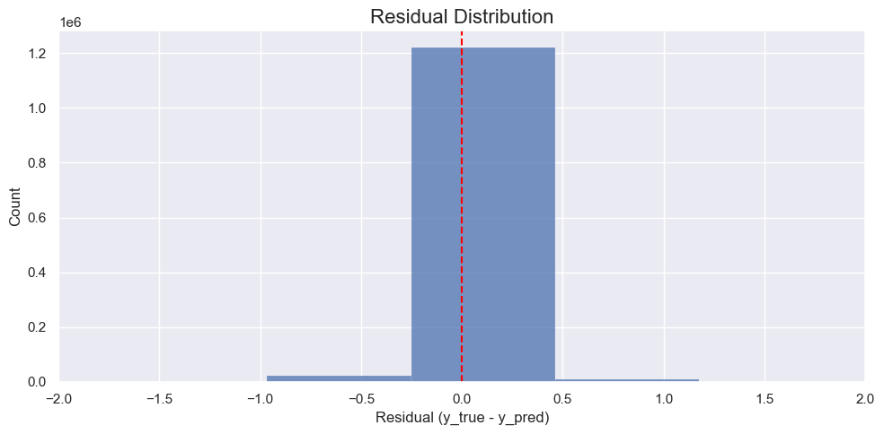

```python
residuals = y_chil_test - pred_orig_chil

plt.figure(figsize=(10, 5))
sns.histplot(residuals, bins=500, kde=False)
plt.axvline(0, color='red', linestyle='--')
plt.title("Residual Distribution", fontsize=16)
plt.xlabel("Residual (y_true - y_pred)", fontsize=12)

plt.xlim(-2, 2)
plt.xticks(fontsize=11)
plt.yticks(fontsize=11)
plt.tight_layout()
plt.show()
```

#### **Error Distribution (Residuals Analysis)**

The residuals (difference between true and predicted **chilled water consumption density** values) help evaluate model accuracy and uncover systematic biases.

We observe the following from the histogram of residuals:

1. **Main Cluster (High Accuracy Zone):**
   - Residuals between **-0.25 and 0.45** account for the **majority of predictions** — approximately **1.21 million rows**.
   - ➤ This indicates that the model makes **highly accurate predictions** for most samples.
2. **small Overprediction Zone:**
   - Residuals between **-0.98 and -0.25** represent a smaller group of predictions — around **20,000 samples**.
   - ➤ These are cases where the model **slightly overestimates** chilled water consumption.
3. **Tails / Outliers:**
   - Residuals outside these ranges have **very low frequency**.
   - ➤ These may correspond to **rare building types, unusual weather patterns, or data quality issues**.

➡️ **Interpretation:**  
The model shows **strong predictive performance overall**, with **errors centered tightly around zero**, and **only a small portion of small or extreme errors**. This suggests both **low bias and low variance** on the validation set.

#### **5. Error analysis by building, time, and weather**

- **Error by building_id**

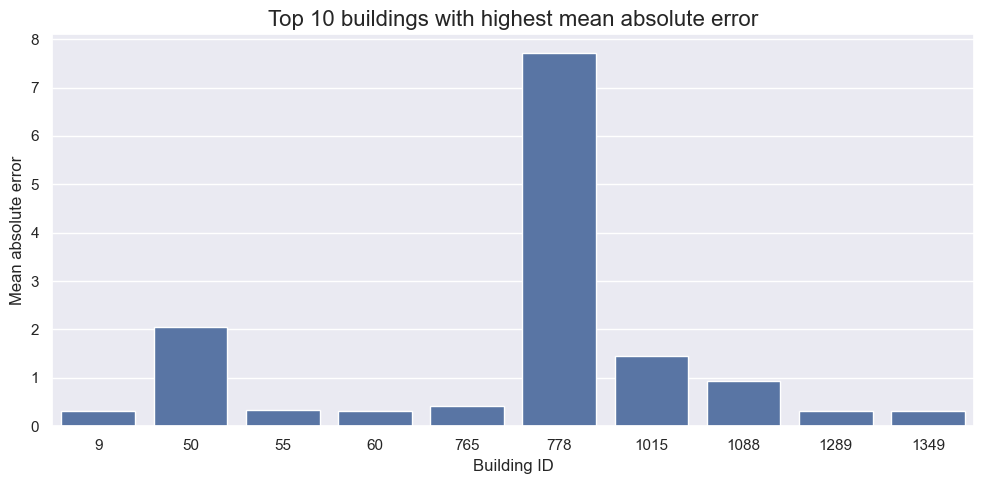

```python
val_df = X_chil_test.copy()

val_df['true'] = y_chil_test.values
val_df['pred'] = pred_orig_chil
val_df['residual'] = val_df['true'] - val_df['pred']

building_errors = val_df.groupby('building_id')['residual'].apply(lambda x: np.mean(np.abs(x)))
top_error_buildings = building_errors.sort_values(ascending=False).head(10)

plt.figure(figsize=(10, 5))
sns.barplot(x=top_error_buildings.index, y=top_error_buildings.values)

plt.title("Top 10 buildings with highest mean absolute error", fontsize=16)
plt.ylabel("Mean absolute error", fontsize=12)
plt.xlabel("Building ID", fontsize=12)
plt.xticks(fontsize=11)
plt.yticks(fontsize=11)
plt.tight_layout()
plt.show()
```

```python
building_errors.sort_values(ascending=False).head(10)
```

```
building_id
778     7.711495
50      2.060415
1015    1.455536
1088    0.935161
765     0.410675
55      0.345742
60      0.320931
1289    0.317178
1349    0.314678
9       0.305476
Name: residual, dtype: float64
```